# R for Data Science Exercise Solutions

Ben Herbertson

Updated 2018-03-01

# 3. Data visualisation

## 3.2.4 Exercises

1. Run `ggplot(data = mpg)`. What do you see?

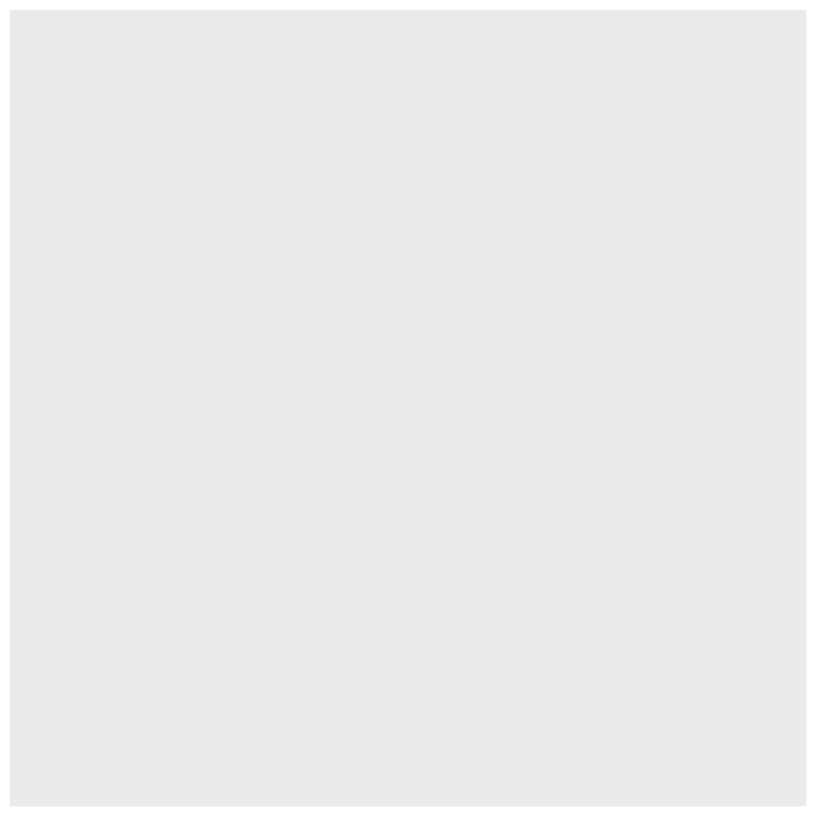

```r
ggplot(data = mpg)
```

Nothing. The plot is empty because no layers have been added to `ggplot()`.

2. How many rows are in `mpg`? How many columns?

```r
mpg
```

```
## # A tibble: 234 x 11
##    manufacturer      model displ  year   cyl      trans   drv   cty   hwy
##           <chr>      <chr> <dbl> <int> <int>      <chr> <chr> <int> <int>
##  1         audi         a4   1.8  1999     4   auto(l5)     f    18    29
##  2         audi         a4   1.8  1999     4 manual(m5)     f    21    29
##  3         audi         a4   2.0  2008     4 manual(m6)     f    20    31
##  4         audi         a4   2.0  2008     4   auto(av)     f    21    30
##  5         audi         a4   2.8  1999     6   auto(l5)     f    16    26
##  6         audi         a4   2.8  1999     6 manual(m5)     f    18    26
##  7         audi         a4   3.1  2008     6   auto(av)     f    18    27
##  8         audi a4 quattro   1.8  1999     4 manual(m5)     4    18    26
##  9         audi a4 quattro   1.8  1999     4   auto(l5)     4    16    25
## 10         audi a4 quattro   2.0  2008     4 manual(m6)     4    20    28
## # ... with 224 more rows, and 2 more variables: fl <chr>, class <chr>
```

234 rows and 11 columns in total.

3. What does the `drv` variable describe? Read the help for `?mpg` to find out.

`drv` describes whether the car is front-wheel drive, rear wheel drive, or 4wd.

4. Make a scatterplot of `hwy` vs `cyl`.

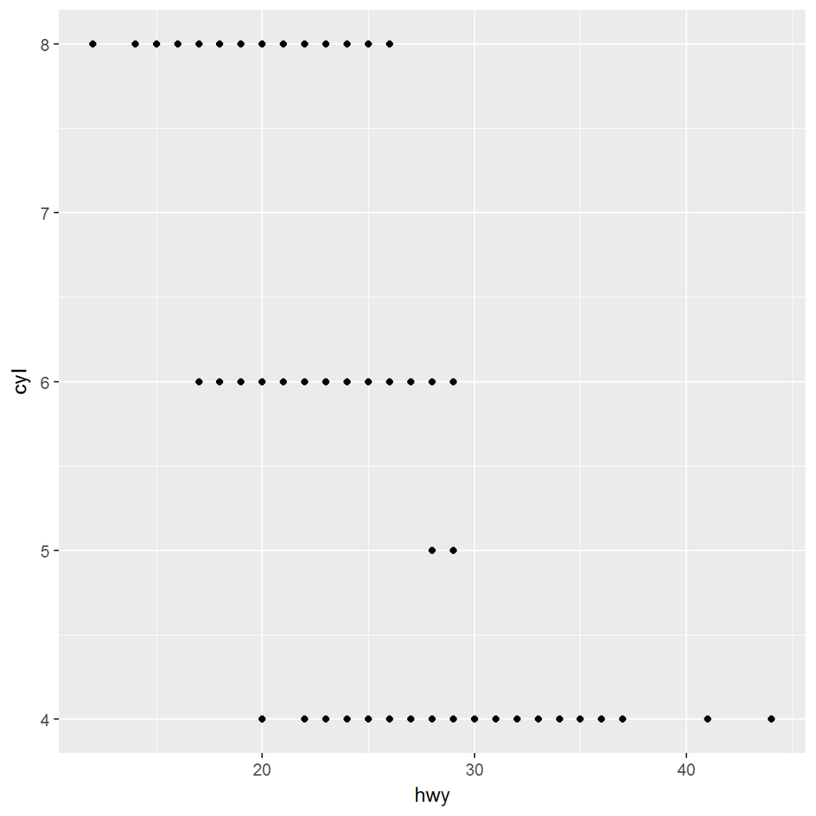

```r
ggplot(mpg, aes(x = hwy, y = cyl)) +
  geom_point()
```

5. What happens if you make a scatterplot of `class` vs `drv`? Why is the plot not useful?

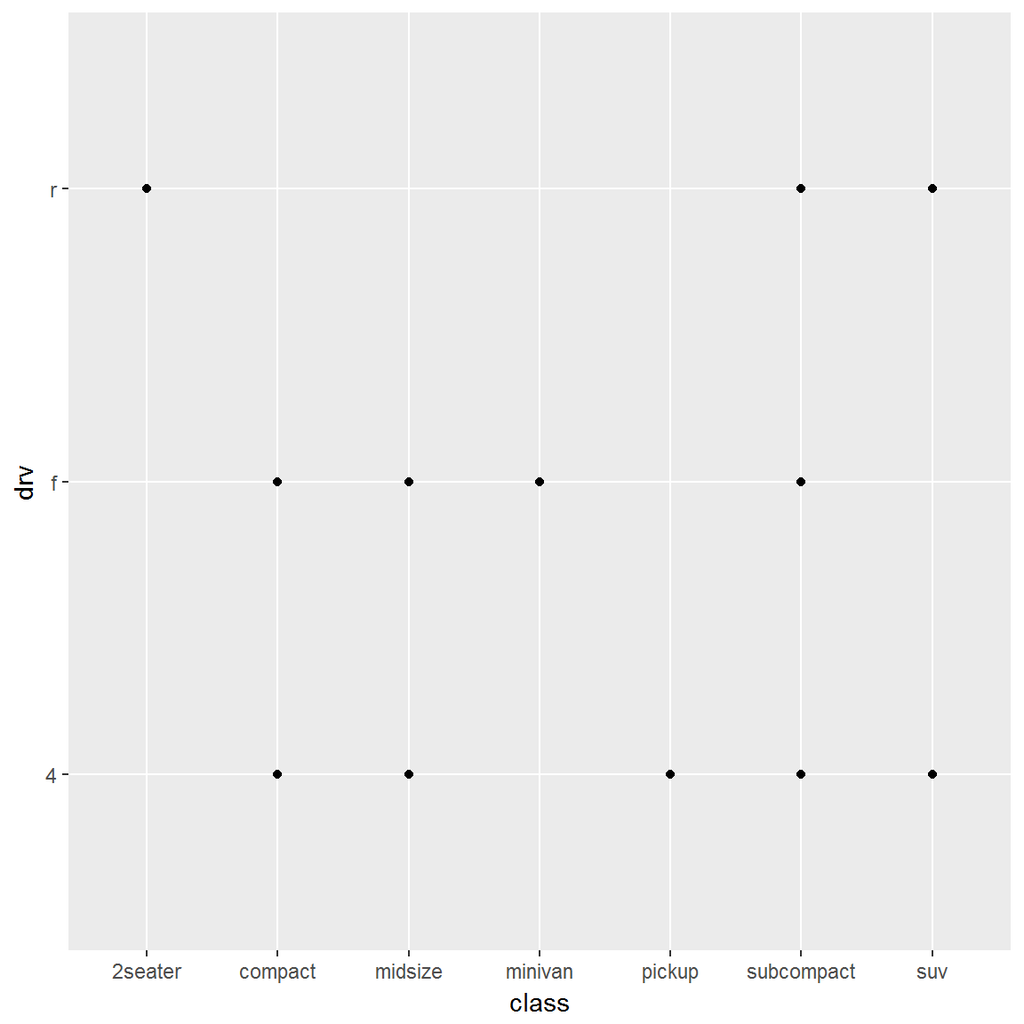

```r
ggplot(mpg, aes(x = class, y = drv)) +
  geom_point()
```

Scatterplots are useful for displaying continuous variables (e.g., `cty` and `hwy`). `class` and `drv` are categorical variables.

## 3.3.1 Exercises

1. What’s gone wrong with this code? Why are the points not blue?

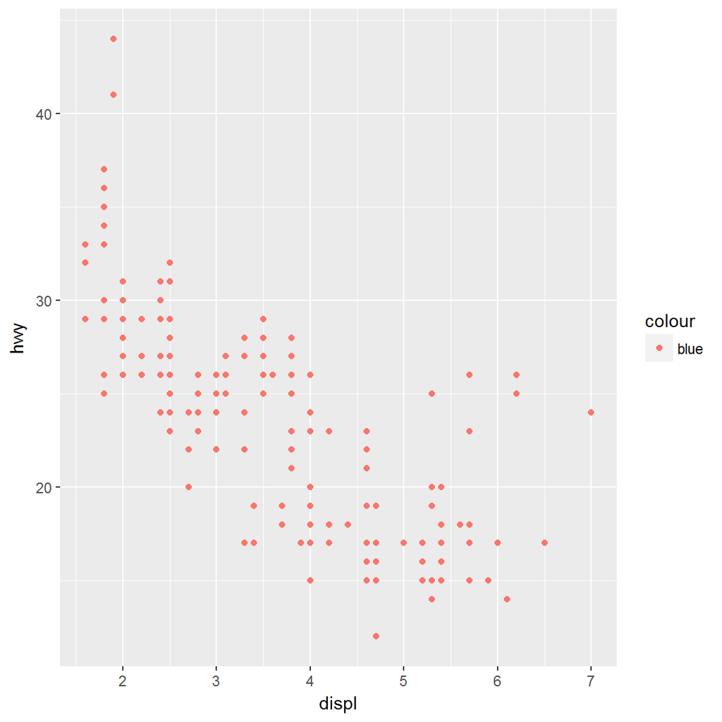

   ```r
   ggplot(data = mpg) +
     geom_point(mapping = aes(x = displ, y = hwy, color = "blue"))
   ```

To make the points blue, colour must be set manually (i.e., it must be located *outside* `aes()`):

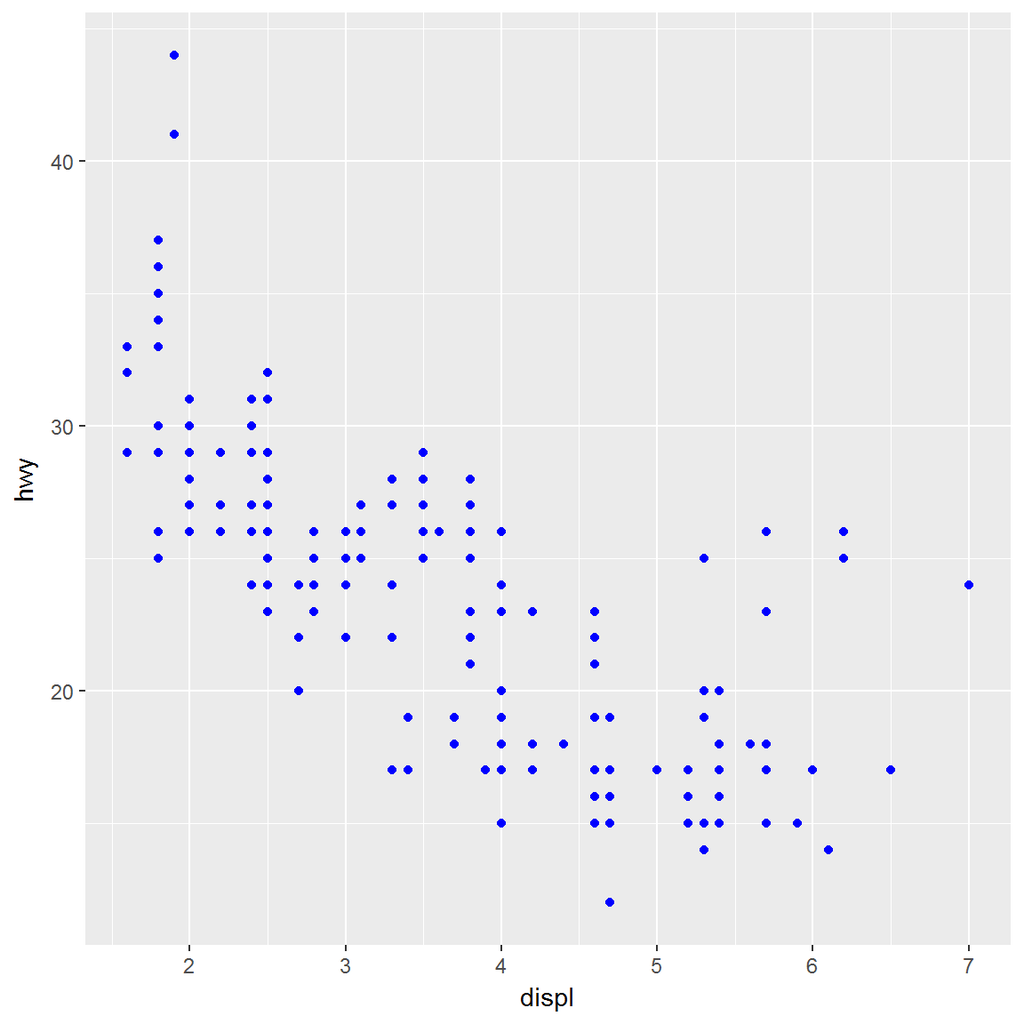

```r
ggplot(data = mpg) +
  geom_point(mapping = aes(x = displ, y = hwy), color = "blue")
```

2. Which variables in `mpg` are categorical? Which variables are continuous? (Hint: type `?mpg` to read the documentation for the dataset). How can you see this information when you run `mpg`?

```r
mpg
```

```
## # A tibble: 234 x 11
##    manufacturer      model displ  year   cyl      trans   drv   cty   hwy
##           <chr>      <chr> <dbl> <int> <int>      <chr> <chr> <int> <int>
##  1         audi         a4   1.8  1999     4   auto(l5)     f    18    29
##  2         audi         a4   1.8  1999     4 manual(m5)     f    21    29
##  3         audi         a4   2.0  2008     4 manual(m6)     f    20    31
##  4         audi         a4   2.0  2008     4   auto(av)     f    21    30
##  5         audi         a4   2.8  1999     6   auto(l5)     f    16    26
##  6         audi         a4   2.8  1999     6 manual(m5)     f    18    26
##  7         audi         a4   3.1  2008     6   auto(av)     f    18    27
##  8         audi a4 quattro   1.8  1999     4 manual(m5)     4    18    26
##  9         audi a4 quattro   1.8  1999     4   auto(l5)     4    16    25
## 10         audi a4 quattro   2.0  2008     4 manual(m6)     4    20    28
## # ... with 224 more rows, and 2 more variables: fl <chr>, class <chr>
```

Categorical: `manufacturer`, `model`, `trans`, `drv`, `fl`, `class`  
Continuous: `displ`, `year`, `cty`, `hwy`

This information is located below the variable name in the output (e.g., `<chr>` indicates a character string which is categorical).

3. Map a continuous variable to `color`, `size`, and `shape`. How do these aesthetics behave differently for categorical vs. continuous variables?
4. What happens if you map the same variable to multiple aesthetics?

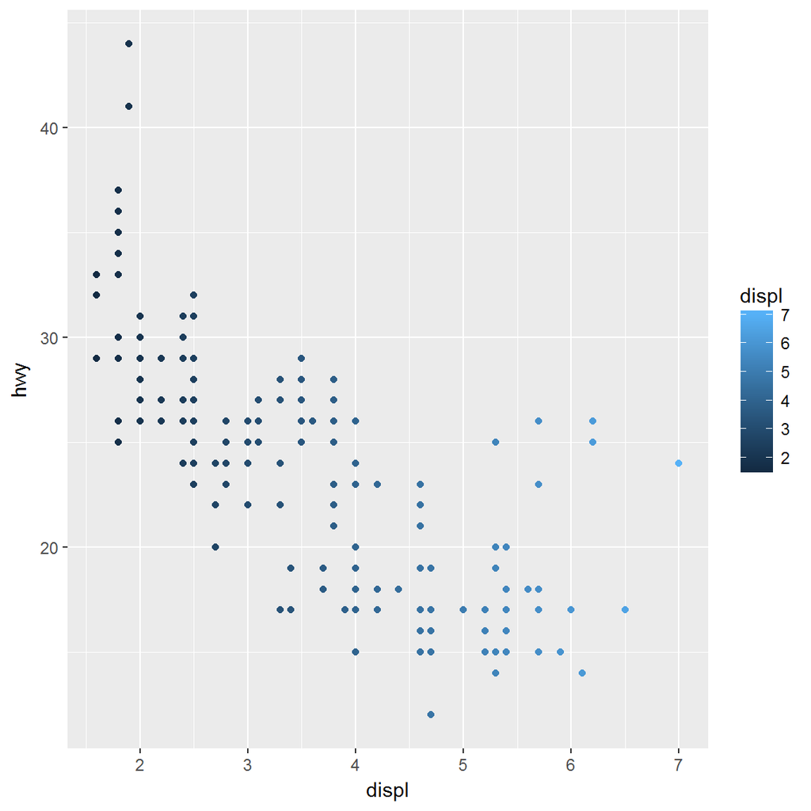

```r
ggplot(data = mpg) +
  geom_point(mapping = aes(x = displ, y = hwy, colour = displ))
```

It creates a gradient along whichever axis the variable is assigned to.

5. What does the `stroke` aesthetic do? What shapes does it work with? (Hint: use `?geom_point`)

`stroke` increases the border width of shapes. However, not all shapes have a border.

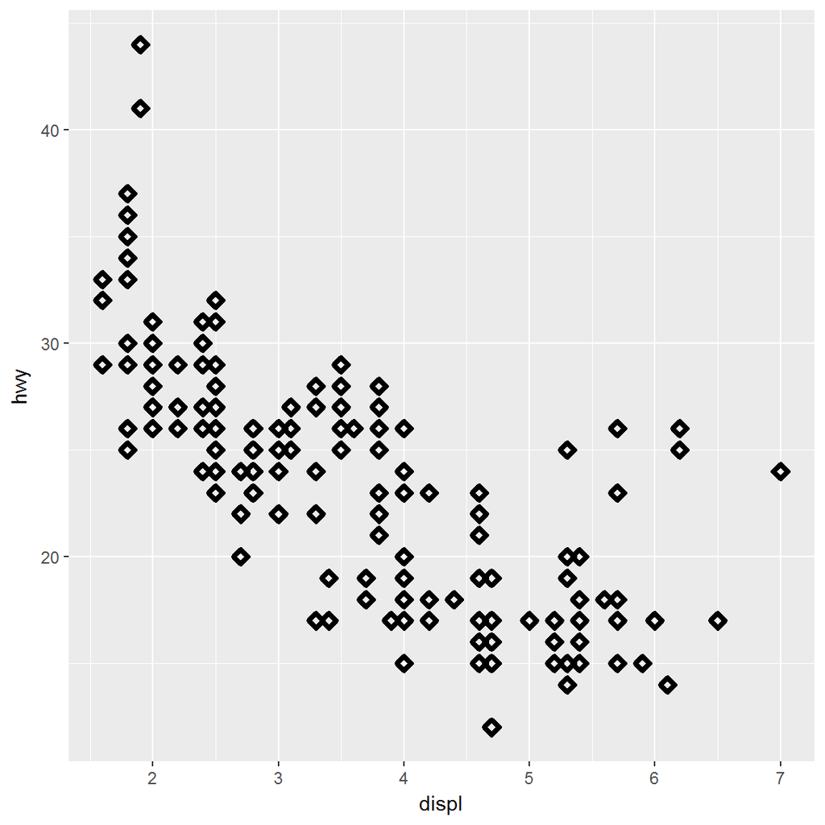

```r
ggplot(data = mpg) +
  geom_point(mapping = aes(x = displ, y = hwy), stroke = 2, shape = 23)
```

6. What happens if you map an aesthetic to something other than a variable name, like `aes(colour = displ < 5)`?

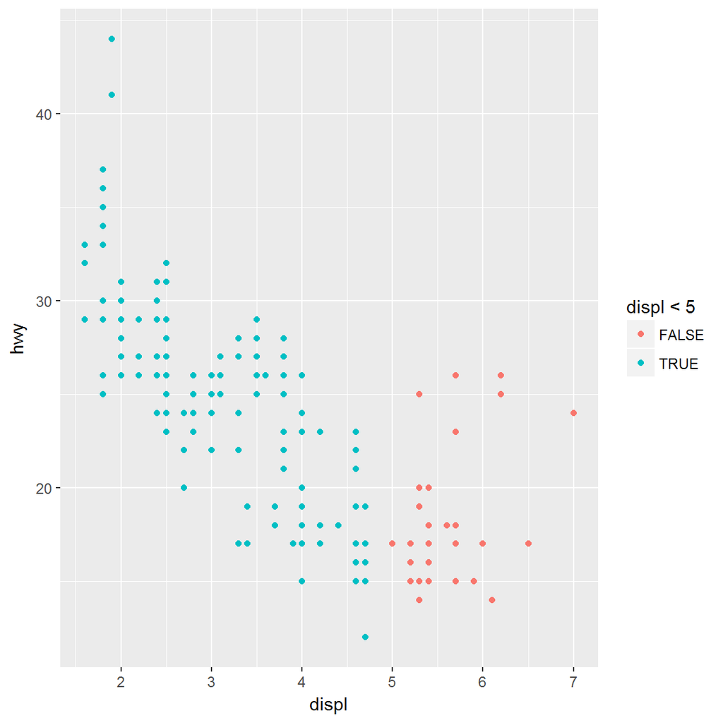

```r
ggplot(data = mpg) +
  geom_point(mapping = aes(x = displ, y = hwy, colour = displ < 5))
```

In this example, each observation with `displ < 5` is grouped together (`TRUE`). All remaining observations form a second group (`FALSE`).

# 4. Workflow: basics

## 4.4 Practice

1. Why does this code not work?

   ```r
   my_variable <- 10
   my_varıable
   ```

   Look carefully! (This may seem like an exercise in pointlessness, but training your brain to notice even the tiniest difference will pay off when programming.)

There is a typo on the second line. It should be `my_variable`, not `my_varıable`.

2. Tweak each of the following R commands so that they run correctly:

   ```r
   library(tidyverse)

   ggplot(dota = mpg) +
     geom_point(mapping = aes(x = displ, y = hwy))

   fliter(mpg, cyl = 8)
   filter(diamond, carat > 3)
   ```

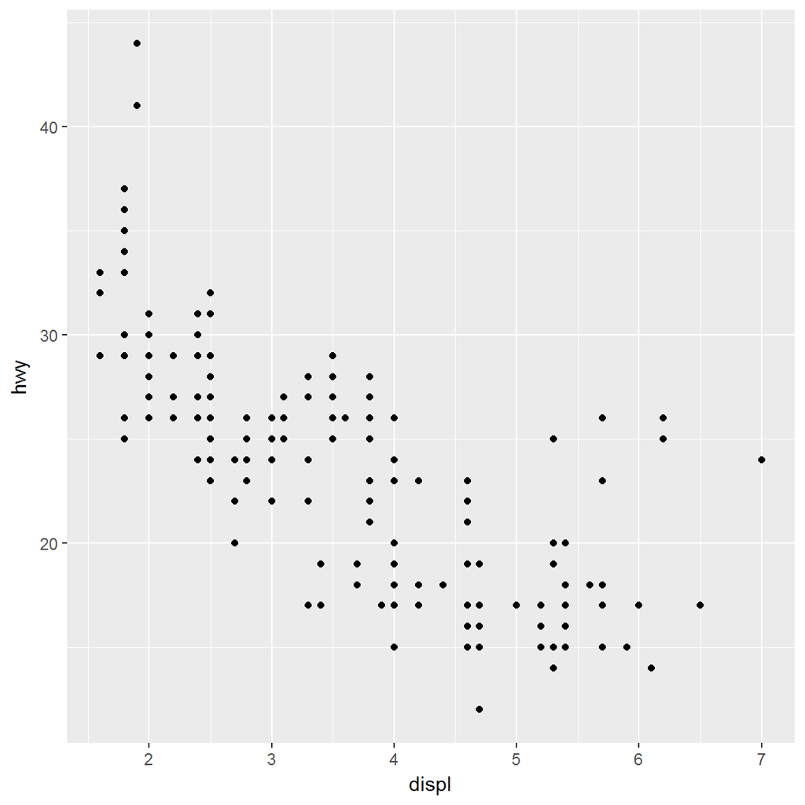

```r
library(tidyverse)

ggplot(data = mpg) +
  geom_point(mapping = aes(x = displ, y = hwy))
```

```r
filter(mpg, cyl == 8)
```

```
## # A tibble: 70 x 11
##    manufacturer              model displ  year   cyl      trans   drv
##           <chr>              <chr> <dbl> <int> <int>      <chr> <chr>
##  1         audi         a6 quattro   4.2  2008     8   auto(s6)     4
##  2    chevrolet c1500 suburban 2wd   5.3  2008     8   auto(l4)     r
##  3    chevrolet c1500 suburban 2wd   5.3  2008     8   auto(l4)     r
##  4    chevrolet c1500 suburban 2wd   5.3  2008     8   auto(l4)     r
##  5    chevrolet c1500 suburban 2wd   5.7  1999     8   auto(l4)     r
##  6    chevrolet c1500 suburban 2wd   6.0  2008     8   auto(l4)     r
##  7    chevrolet           corvette   5.7  1999     8 manual(m6)     r
##  8    chevrolet           corvette   5.7  1999     8   auto(l4)     r
##  9    chevrolet           corvette   6.2  2008     8 manual(m6)     r
## 10    chevrolet           corvette   6.2  2008     8   auto(s6)     r
## # ... with 60 more rows, and 4 more variables: cty <int>, hwy <int>,
## #   fl <chr>, class <chr>
```

```r
filter(diamonds, carat > 3)
```

```
## # A tibble: 32 x 10
##    carat     cut color clarity depth table price     x     y     z
##    <dbl>   <ord> <ord>   <ord> <dbl> <dbl> <int> <dbl> <dbl> <dbl>
##  1  3.01 Premium     I      I1  62.7    58  8040  9.10  8.97  5.67
##  2  3.11    Fair     J      I1  65.9    57  9823  9.15  9.02  5.98
##  3  3.01 Premium     F      I1  62.2    56  9925  9.24  9.13  5.73
##  4  3.05 Premium     E      I1  60.9    58 10453  9.26  9.25  5.66
##  5  3.02    Fair     I      I1  65.2    56 10577  9.11  9.02  5.91
##  6  3.01    Fair     H      I1  56.1    62 10761  9.54  9.38  5.31
##  7  3.65    Fair     H      I1  67.1    53 11668  9.53  9.48  6.38
##  8  3.24 Premium     H      I1  62.1    58 12300  9.44  9.40  5.85
##  9  3.22   Ideal     I      I1  62.6    55 12545  9.49  9.42  5.92
## 10  3.50   Ideal     H      I1  62.8    57 12587  9.65  9.59  6.03
## # ... with 22 more rows
```

3. Press Alt + Shift + K. What happens? How can you get to the same place using the menus?

*The Keyboard Shortcut Quick Reference* overlay appears.

# 5. Data transformation

## 5.2.4 Exercises

1. Find all flights that
   1. Had an arrival delay of two or more hours
   2. Flew to Houston (`IAH` or `HOU`)
   3. Were operated by United, American, or Delta
   4. Departed in summer (July, August, and September)
   5. Arrived more than two hours late, but didn’t leave late
   6. Were delayed by at least an hour, but made up over 30 minutes in flight
   7. Departed between midnight and 6am (inclusive)

Had an arrival delay of two or more hours:

```r
filter(flights, arr_delay >= 120)
```

```
## # A tibble: 10,200 x 19
##     year month   day dep_time sched_dep_time dep_delay arr_time
##    <int> <int> <int>    <int>          <int>     <dbl>    <int>
##  1  2013     1     1      811            630       101     1047
##  2  2013     1     1      848           1835       853     1001
##  3  2013     1     1      957            733       144     1056
##  4  2013     1     1     1114            900       134     1447
##  5  2013     1     1     1505           1310       115     1638
##  6  2013     1     1     1525           1340       105     1831
##  7  2013     1     1     1549           1445        64     1912
##  8  2013     1     1     1558           1359       119     1718
##  9  2013     1     1     1732           1630        62     2028
## 10  2013     1     1     1803           1620       103     2008
## # ... with 10,190 more rows, and 12 more variables: sched_arr_time <int>,
## #   arr_delay <dbl>, carrier <chr>, flight <int>, tailnum <chr>,
## #   origin <chr>, dest <chr>, air_time <dbl>, distance <dbl>, hour <dbl>,
## #   minute <dbl>, time_hour <dttm>
```

Flew to Houston (`IAH` or `HOU`):

```r
filter(flights, dest %in% c("IAH", "HOU"))
```

```
## # A tibble: 9,313 x 19
##     year month   day dep_time sched_dep_time dep_delay arr_time
##    <int> <int> <int>    <int>          <int>     <dbl>    <int>
##  1  2013     1     1      517            515         2      830
##  2  2013     1     1      533            529         4      850
##  3  2013     1     1      623            627        -4      933
##  4  2013     1     1      728            732        -4     1041
##  5  2013     1     1      739            739         0     1104
##  6  2013     1     1      908            908         0     1228
##  7  2013     1     1     1028           1026         2     1350
##  8  2013     1     1     1044           1045        -1     1352
##  9  2013     1     1     1114            900       134     1447
## 10  2013     1     1     1205           1200         5     1503
## # ... with 9,303 more rows, and 12 more variables: sched_arr_time <int>,
## #   arr_delay <dbl>, carrier <chr>, flight <int>, tailnum <chr>,
## #   origin <chr>, dest <chr>, air_time <dbl>, distance <dbl>, hour <dbl>,
## #   minute <dbl>, time_hour <dttm>
```

Were operated by United, American, or Delta:

```r
filter(flights, carrier %in% c("UA", "AA", "DL"))
```

```
## # A tibble: 139,504 x 19
##     year month   day dep_time sched_dep_time dep_delay arr_time
##    <int> <int> <int>    <int>          <int>     <dbl>    <int>
##  1  2013     1     1      517            515         2      830
##  2  2013     1     1      533            529         4      850
##  3  2013     1     1      542            540         2      923
##  4  2013     1     1      554            600        -6      812
##  5  2013     1     1      554            558        -4      740
##  6  2013     1     1      558            600        -2      753
##  7  2013     1     1      558            600        -2      924
##  8  2013     1     1      558            600        -2      923
##  9  2013     1     1      559            600        -1      941
## 10  2013     1     1      559            600        -1      854
## # ... with 139,494 more rows, and 12 more variables: sched_arr_time <int>,
## #   arr_delay <dbl>, carrier <chr>, flight <int>, tailnum <chr>,
## #   origin <chr>, dest <chr>, air_time <dbl>, distance <dbl>, hour <dbl>,
## #   minute <dbl>, time_hour <dttm>
```

(To find the two letter carrier abbreviations, see `airlines`.)

Departed in summer (July, August, and September):

```r
filter(flights, month %in% c(7, 8, 9))
```

```
## # A tibble: 86,326 x 19
##     year month   day dep_time sched_dep_time dep_delay arr_time
##    <int> <int> <int>    <int>          <int>     <dbl>    <int>
##  1  2013     7     1        1           2029       212      236
##  2  2013     7     1        2           2359         3      344
##  3  2013     7     1       29           2245       104      151
##  4  2013     7     1       43           2130       193      322
##  5  2013     7     1       44           2150       174      300
##  6  2013     7     1       46           2051       235      304
##  7  2013     7     1       48           2001       287      308
##  8  2013     7     1       58           2155       183      335
##  9  2013     7     1      100           2146       194      327
## 10  2013     7     1      100           2245       135      337
## # ... with 86,316 more rows, and 12 more variables: sched_arr_time <int>,
## #   arr_delay <dbl>, carrier <chr>, flight <int>, tailnum <chr>,
## #   origin <chr>, dest <chr>, air_time <dbl>, distance <dbl>, hour <dbl>,
## #   minute <dbl>, time_hour <dttm>
```

Arrived more than two hours late, but didn’t leave late:

```r
filter(flights, arr_delay >= 120 & dep_delay <= 0)
```

```
## # A tibble: 29 x 19
##     year month   day dep_time sched_dep_time dep_delay arr_time
##    <int> <int> <int>    <int>          <int>     <dbl>    <int>
##  1  2013     1    27     1419           1420        -1     1754
##  2  2013    10     7     1350           1350         0     1736
##  3  2013    10     7     1357           1359        -2     1858
##  4  2013    10    16      657            700        -3     1258
##  5  2013    11     1      658            700        -2     1329
##  6  2013     3    18     1844           1847        -3       39
##  7  2013     4    17     1635           1640        -5     2049
##  8  2013     4    18      558            600        -2     1149
##  9  2013     4    18      655            700        -5     1213
## 10  2013     5    22     1827           1830        -3     2217
## # ... with 19 more rows, and 12 more variables: sched_arr_time <int>,
## #   arr_delay <dbl>, carrier <chr>, flight <int>, tailnum <chr>,
## #   origin <chr>, dest <chr>, air_time <dbl>, distance <dbl>, hour <dbl>,
## #   minute <dbl>, time_hour <dttm>
```

Were delayed by at least an hour, but made up over 30 minutes in flight:

```r
filter(flights, dep_delay >= 60  & dep_delay - arr_delay > 30)
```

```
## # A tibble: 1,844 x 19
##     year month   day dep_time sched_dep_time dep_delay arr_time
##    <int> <int> <int>    <int>          <int>     <dbl>    <int>
##  1  2013     1     1     2205           1720       285       46
##  2  2013     1     1     2326           2130       116      131
##  3  2013     1     3     1503           1221       162     1803
##  4  2013     1     3     1839           1700        99     2056
##  5  2013     1     3     1850           1745        65     2148
##  6  2013     1     3     1941           1759       102     2246
##  7  2013     1     3     1950           1845        65     2228
##  8  2013     1     3     2015           1915        60     2135
##  9  2013     1     3     2257           2000       177       45
## 10  2013     1     4     1917           1700       137     2135
## # ... with 1,834 more rows, and 12 more variables: sched_arr_time <int>,
## #   arr_delay <dbl>, carrier <chr>, flight <int>, tailnum <chr>,
## #   origin <chr>, dest <chr>, air_time <dbl>, distance <dbl>, hour <dbl>,
## #   minute <dbl>, time_hour <dttm>
```

Departed between midnight and 6am (inclusive):

```r
filter(flights, dep_time <= 600 | dep_time == 2400)
```

```
## # A tibble: 9,373 x 19
##     year month   day dep_time sched_dep_time dep_delay arr_time
##    <int> <int> <int>    <int>          <int>     <dbl>    <int>
##  1  2013     1     1      517            515         2      830
##  2  2013     1     1      533            529         4      850
##  3  2013     1     1      542            540         2      923
##  4  2013     1     1      544            545        -1     1004
##  5  2013     1     1      554            600        -6      812
##  6  2013     1     1      554            558        -4      740
##  7  2013     1     1      555            600        -5      913
##  8  2013     1     1      557            600        -3      709
##  9  2013     1     1      557            600        -3      838
## 10  2013     1     1      558            600        -2      753
## # ... with 9,363 more rows, and 12 more variables: sched_arr_time <int>,
## #   arr_delay <dbl>, carrier <chr>, flight <int>, tailnum <chr>,
## #   origin <chr>, dest <chr>, air_time <dbl>, distance <dbl>, hour <dbl>,
## #   minute <dbl>, time_hour <dttm>
```

2. Another useful dplyr filtering helper is `between()`. What does it do? Can you use it to simplify the code needed to answer the previous challenges?

It is a shortcut for finding values that fall within a specified range:

```r
filter(flights, between(month, 7, 9))
```

```
## # A tibble: 86,326 x 19
##     year month   day dep_time sched_dep_time dep_delay arr_time
##    <int> <int> <int>    <int>          <int>     <dbl>    <int>
##  1  2013     7     1        1           2029       212      236
##  2  2013     7     1        2           2359         3      344
##  3  2013     7     1       29           2245       104      151
##  4  2013     7     1       43           2130       193      322
##  5  2013     7     1       44           2150       174      300
##  6  2013     7     1       46           2051       235      304
##  7  2013     7     1       48           2001       287      308
##  8  2013     7     1       58           2155       183      335
##  9  2013     7     1      100           2146       194      327
## 10  2013     7     1      100           2245       135      337
## # ... with 86,316 more rows, and 12 more variables: sched_arr_time <int>,
## #   arr_delay <dbl>, carrier <chr>, flight <int>, tailnum <chr>,
## #   origin <chr>, dest <chr>, air_time <dbl>, distance <dbl>, hour <dbl>,
## #   minute <dbl>, time_hour <dttm>
```

3. How many flights have a missing `dep_time`? What other variables are missing? What might these rows represent?

```r
filter(flights, is.na(dep_time))
```

```
## # A tibble: 8,255 x 19
##     year month   day dep_time sched_dep_time dep_delay arr_time
##    <int> <int> <int>    <int>          <int>     <dbl>    <int>
##  1  2013     1     1       NA           1630        NA       NA
##  2  2013     1     1       NA           1935        NA       NA
##  3  2013     1     1       NA           1500        NA       NA
##  4  2013     1     1       NA            600        NA       NA
##  5  2013     1     2       NA           1540        NA       NA
##  6  2013     1     2       NA           1620        NA       NA
##  7  2013     1     2       NA           1355        NA       NA
##  8  2013     1     2       NA           1420        NA       NA
##  9  2013     1     2       NA           1321        NA       NA
## 10  2013     1     2       NA           1545        NA       NA
## # ... with 8,245 more rows, and 12 more variables: sched_arr_time <int>,
## #   arr_delay <dbl>, carrier <chr>, flight <int>, tailnum <chr>,
## #   origin <chr>, dest <chr>, air_time <dbl>, distance <dbl>, hour <dbl>,
## #   minute <dbl>, time_hour <dttm>
```

8,255 flights.

To see what other variables are missing, you can use `View()`:

```r
View(filter(flights, is.na(dep_time)))
```

`dep_delay`, `arr_time`, `arr_delay`, and `air_time` are also missing. These flights were most likely cancelled.

4. Why is `NA ^ 0` not missing? Why is `NA | TRUE` not missing? Why is `FALSE & NA` not missing? Can you figure out the general rule? (`NA * 0` is a tricky counterexample!)

See Jeffrey Arnold’s [explanation](https://jrnold.github.io/r4ds-exercise-solutions/data-transformation.html#filter).

## 5.3.1 Exercises

1. How could you use `arrange()` to sort all missing values to the start? (Hint: use `is.na()`).

```r
arrange(flights, desc(is.na(dep_time)))
```

```
## # A tibble: 336,776 x 19
##     year month   day dep_time sched_dep_time dep_delay arr_time
##    <int> <int> <int>    <int>          <int>     <dbl>    <int>
##  1  2013     1     1       NA           1630        NA       NA
##  2  2013     1     1       NA           1935        NA       NA
##  3  2013     1     1       NA           1500        NA       NA
##  4  2013     1     1       NA            600        NA       NA
##  5  2013     1     2       NA           1540        NA       NA
##  6  2013     1     2       NA           1620        NA       NA
##  7  2013     1     2       NA           1355        NA       NA
##  8  2013     1     2       NA           1420        NA       NA
##  9  2013     1     2       NA           1321        NA       NA
## 10  2013     1     2       NA           1545        NA       NA
## # ... with 336,766 more rows, and 12 more variables: sched_arr_time <int>,
## #   arr_delay <dbl>, carrier <chr>, flight <int>, tailnum <chr>,
## #   origin <chr>, dest <chr>, air_time <dbl>, distance <dbl>, hour <dbl>,
## #   minute <dbl>, time_hour <dttm>
```

2. Sort `flights` to find the most delayed flights. Find the flights that left earliest.

```r
arrange(flights, desc(dep_delay))
```

```
## # A tibble: 336,776 x 19
##     year month   day dep_time sched_dep_time dep_delay arr_time
##    <int> <int> <int>    <int>          <int>     <dbl>    <int>
##  1  2013     1     9      641            900      1301     1242
##  2  2013     6    15     1432           1935      1137     1607
##  3  2013     1    10     1121           1635      1126     1239
##  4  2013     9    20     1139           1845      1014     1457
##  5  2013     7    22      845           1600      1005     1044
##  6  2013     4    10     1100           1900       960     1342
##  7  2013     3    17     2321            810       911      135
##  8  2013     6    27      959           1900       899     1236
##  9  2013     7    22     2257            759       898      121
## 10  2013    12     5      756           1700       896     1058
## # ... with 336,766 more rows, and 12 more variables: sched_arr_time <int>,
## #   arr_delay <dbl>, carrier <chr>, flight <int>, tailnum <chr>,
## #   origin <chr>, dest <chr>, air_time <dbl>, distance <dbl>, hour <dbl>,
## #   minute <dbl>, time_hour <dttm>
```

```r
arrange(flights, dep_delay)
```

```
## # A tibble: 336,776 x 19
##     year month   day dep_time sched_dep_time dep_delay arr_time
##    <int> <int> <int>    <int>          <int>     <dbl>    <int>
##  1  2013    12     7     2040           2123       -43       40
##  2  2013     2     3     2022           2055       -33     2240
##  3  2013    11    10     1408           1440       -32     1549
##  4  2013     1    11     1900           1930       -30     2233
##  5  2013     1    29     1703           1730       -27     1947
##  6  2013     8     9      729            755       -26     1002
##  7  2013    10    23     1907           1932       -25     2143
##  8  2013     3    30     2030           2055       -25     2213
##  9  2013     3     2     1431           1455       -24     1601
## 10  2013     5     5      934            958       -24     1225
## # ... with 336,766 more rows, and 12 more variables: sched_arr_time <int>,
## #   arr_delay <dbl>, carrier <chr>, flight <int>, tailnum <chr>,
## #   origin <chr>, dest <chr>, air_time <dbl>, distance <dbl>, hour <dbl>,
## #   minute <dbl>, time_hour <dttm>
```

3. Sort `flights` to find the fastest flights.

This depends how you define “fastest flights”. It could refer to the least amount of `air_time`:

```r
arrange(flights, air_time)
```

```
## # A tibble: 336,776 x 19
##     year month   day dep_time sched_dep_time dep_delay arr_time
##    <int> <int> <int>    <int>          <int>     <dbl>    <int>
##  1  2013     1    16     1355           1315        40     1442
##  2  2013     4    13      537            527        10      622
##  3  2013    12     6      922            851        31     1021
##  4  2013     2     3     2153           2129        24     2247
##  5  2013     2     5     1303           1315       -12     1342
##  6  2013     2    12     2123           2130        -7     2211
##  7  2013     3     2     1450           1500       -10     1547
##  8  2013     3     8     2026           1935        51     2131
##  9  2013     3    18     1456           1329        87     1533
## 10  2013     3    19     2226           2145        41     2305
## # ... with 336,766 more rows, and 12 more variables: sched_arr_time <int>,
## #   arr_delay <dbl>, carrier <chr>, flight <int>, tailnum <chr>,
## #   origin <chr>, dest <chr>, air_time <dbl>, distance <dbl>, hour <dbl>,
## #   minute <dbl>, time_hour <dttm>
```

4. Which flights travelled the longest? Which travelled the shortest?

If we assume this refers to distance travelled:

```r
arrange(flights, desc(distance))
```

```
## # A tibble: 336,776 x 19
##     year month   day dep_time sched_dep_time dep_delay arr_time
##    <int> <int> <int>    <int>          <int>     <dbl>    <int>
##  1  2013     1     1      857            900        -3     1516
##  2  2013     1     2      909            900         9     1525
##  3  2013     1     3      914            900        14     1504
##  4  2013     1     4      900            900         0     1516
##  5  2013     1     5      858            900        -2     1519
##  6  2013     1     6     1019            900        79     1558
##  7  2013     1     7     1042            900       102     1620
##  8  2013     1     8      901            900         1     1504
##  9  2013     1     9      641            900      1301     1242
## 10  2013     1    10      859            900        -1     1449
## # ... with 336,766 more rows, and 12 more variables: sched_arr_time <int>,
## #   arr_delay <dbl>, carrier <chr>, flight <int>, tailnum <chr>,
## #   origin <chr>, dest <chr>, air_time <dbl>, distance <dbl>, hour <dbl>,
## #   minute <dbl>, time_hour <dttm>
```

The longest flight is from JFK to HNL (Honolulu) at 4983 miles.

```r
arrange(flights, distance)
```

```
## # A tibble: 336,776 x 19
##     year month   day dep_time sched_dep_time dep_delay arr_time
##    <int> <int> <int>    <int>          <int>     <dbl>    <int>
##  1  2013     7    27       NA            106        NA       NA
##  2  2013     1     3     2127           2129        -2     2222
##  3  2013     1     4     1240           1200        40     1333
##  4  2013     1     4     1829           1615       134     1937
##  5  2013     1     4     2128           2129        -1     2218
##  6  2013     1     5     1155           1200        -5     1241
##  7  2013     1     6     2125           2129        -4     2224
##  8  2013     1     7     2124           2129        -5     2212
##  9  2013     1     8     2127           2130        -3     2304
## 10  2013     1     9     2126           2129        -3     2217
## # ... with 336,766 more rows, and 12 more variables: sched_arr_time <int>,
## #   arr_delay <dbl>, carrier <chr>, flight <int>, tailnum <chr>,
## #   origin <chr>, dest <chr>, air_time <dbl>, distance <dbl>, hour <dbl>,
## #   minute <dbl>, time_hour <dttm>
```

The shortest flight is from EWR (Newark) to LGA (La Guardia) at 17 miles, however this appears to be a cancelled flight (a number of variables such as `dep_time` are missing). The next shortest flight is from EWR to PHL (Philadelphia) at 80 miles.

(See `airports` to find the names that correspond to the FAA airport code.)

## 5.4.1 Exercises

1. Brainstorm as many ways as possible to select `dep_time`, `dep_delay`, `arr_time`, and `arr_delay` from `flights`.

```r
select(flights, dep_time, dep_delay, arr_time, arr_delay)
```

```
## # A tibble: 336,776 x 4
##    dep_time dep_delay arr_time arr_delay
##       <int>     <dbl>    <int>     <dbl>
##  1      517         2      830        11
##  2      533         4      850        20
##  3      542         2      923        33
##  4      544        -1     1004       -18
##  5      554        -6      812       -25
##  6      554        -4      740        12
##  7      555        -5      913        19
##  8      557        -3      709       -14
##  9      557        -3      838        -8
## 10      558        -2      753         8
## # ... with 336,766 more rows
```

```r
select(flights, starts_with("dep"), starts_with("arr"))
```

```
## # A tibble: 336,776 x 4
##    dep_time dep_delay arr_time arr_delay
##       <int>     <dbl>    <int>     <dbl>
##  1      517         2      830        11
##  2      533         4      850        20
##  3      542         2      923        33
##  4      544        -1     1004       -18
##  5      554        -6      812       -25
##  6      554        -4      740        12
##  7      555        -5      913        19
##  8      557        -3      709       -14
##  9      557        -3      838        -8
## 10      558        -2      753         8
## # ... with 336,766 more rows
```

2. What happens if you include the name of a variable multiple times in a `select()` call?

It will only print once.

```r
select(flights, dep_time, dep_time)
```

```
## # A tibble: 336,776 x 1
##    dep_time
##       <int>
##  1      517
##  2      533
##  3      542
##  4      544
##  5      554
##  6      554
##  7      555
##  8      557
##  9      557
## 10      558
## # ... with 336,766 more rows
```

3. What does the `one_of()` function do? Why might it be helpful in conjunction with this vector?

   ```r
   vars <- c("year", "month", "day", "dep_delay", "arr_delay")
   ```

The `one_of()` function allows you to use variables stored in a character vector:

```r
select(flights, one_of(vars))
```

```
## # A tibble: 336,776 x 5
##     year month   day dep_delay arr_delay
##    <int> <int> <int>     <dbl>     <dbl>
##  1  2013     1     1         2        11
##  2  2013     1     1         4        20
##  3  2013     1     1         2        33
##  4  2013     1     1        -1       -18
##  5  2013     1     1        -6       -25
##  6  2013     1     1        -4        12
##  7  2013     1     1        -5        19
##  8  2013     1     1        -3       -14
##  9  2013     1     1        -3        -8
## 10  2013     1     1        -2         8
## # ... with 336,766 more rows
```

It improves the readability of code.

4. Does the result of running the following code surprise you? How do the select helpers deal with case by default? How can you change that default?

   ```r
   select(flights, contains("TIME"))
   ```

Select helpers are not case sensitive by default. To change the default, use `ignore.case = FALSE`.

## 5.5.2 Exercises

1. Currently `dep_time` and `sched_dep_time` are convenient to look at, but hard to compute with because they’re not really continuous numbers. Convert them to a more convenient representation of number of minutes since midnight.

```r
transmute(flights,
  dep_time,
  hour = dep_time %/% 100,
  minute = dep_time %% 100,
  dep_time_mins = (hour * 60) + minute
)
```

```
## # A tibble: 336,776 x 4
##    dep_time  hour minute dep_time_mins
##       <int> <dbl>  <dbl>         <dbl>
##  1      517     5     17           317
##  2      533     5     33           333
##  3      542     5     42           342
##  4      544     5     44           344
##  5      554     5     54           354
##  6      554     5     54           354
##  7      555     5     55           355
##  8      557     5     57           357
##  9      557     5     57           357
## 10      558     5     58           358
## # ... with 336,766 more rows
```

```r
transmute(flights,
  sched_dep_time,
  hour = sched_dep_time %/% 100,
  minute = sched_dep_time %% 100,
  sched_dep_mins = (hour * 60) + minute
)
```

```
## # A tibble: 336,776 x 4
##    sched_dep_time  hour minute sched_dep_mins
##             <int> <dbl>  <dbl>          <dbl>
##  1            515     5     15            315
##  2            529     5     29            329
##  3            540     5     40            340
##  4            545     5     45            345
##  5            600     6      0            360
##  6            558     5     58            358
##  7            600     6      0            360
##  8            600     6      0            360
##  9            600     6      0            360
## 10            600     6      0            360
## # ... with 336,766 more rows
```

2. Compare `air_time` with `arr_time - dep_time`. What do you expect to see? What do you see? What do you need to do to fix it?

```r
transmute(flights, air_time, arr_time - dep_time)
```

```
## # A tibble: 336,776 x 2
##    air_time `arr_time - dep_time`
##       <dbl>                 <int>
##  1      227                   313
##  2      227                   317
##  3      160                   381
##  4      183                   460
##  5      116                   258
##  6      150                   186
##  7      158                   358
##  8       53                   152
##  9      140                   281
## 10      138                   195
## # ... with 336,766 more rows
```

You would expect `arr_time - dep_time == air_time`. This discrepancy is explained by timezone differences. `arr_time` and `dep_time` are in local timezones that may differ.

3. Compare `dep_time`, `sched_dep_time`, and `dep_delay`. How would you expect those three numbers to be related?

```r
select(flights, dep_time, sched_dep_time, dep_delay)
```

```
## # A tibble: 336,776 x 3
##    dep_time sched_dep_time dep_delay
##       <int>          <int>     <dbl>
##  1      517            515         2
##  2      533            529         4
##  3      542            540         2
##  4      544            545        -1
##  5      554            600        -6
##  6      554            558        -4
##  7      555            600        -5
##  8      557            600        -3
##  9      557            600        -3
## 10      558            600        -2
## # ... with 336,766 more rows
```

`dep_time - sched_dep_time == dep_delay`.

4. Find the 10 most delayed flights using a ranking function. How do you want to handle ties? Carefully read the documentation for `min_rank()`.

```r
flights_ranked <- mutate(flights, rank = min_rank(-dep_delay))
arrange(flights_ranked, desc(dep_delay))
```

```
## # A tibble: 336,776 x 20
##     year month   day dep_time sched_dep_time dep_delay arr_time
##    <int> <int> <int>    <int>          <int>     <dbl>    <int>
##  1  2013     1     9      641            900      1301     1242
##  2  2013     6    15     1432           1935      1137     1607
##  3  2013     1    10     1121           1635      1126     1239
##  4  2013     9    20     1139           1845      1014     1457
##  5  2013     7    22      845           1600      1005     1044
##  6  2013     4    10     1100           1900       960     1342
##  7  2013     3    17     2321            810       911      135
##  8  2013     6    27      959           1900       899     1236
##  9  2013     7    22     2257            759       898      121
## 10  2013    12     5      756           1700       896     1058
## # ... with 336,766 more rows, and 13 more variables: sched_arr_time <int>,
## #   arr_delay <dbl>, carrier <chr>, flight <int>, tailnum <chr>,
## #   origin <chr>, dest <chr>, air_time <dbl>, distance <dbl>, hour <dbl>,
## #   minute <dbl>, time_hour <dttm>, rank <int>
```

Ties should be assigned the lowest rank. `ties.method = "min"` is the default for `min_rank()`.

5. What does `1:3 + 1:10` return? Why?

```r
1:3 + 1:10
```

```
##  [1]  2  4  6  5  7  9  8 10 12 11
```

1 + 1 = 2; 2 + 2 = 4; 3 + 3 = 6; 4 + 1 = 5; 5 + 2 = 7, and so on.

6. What trigonometric functions does R provide?

Cosine, sine, tangent, arc-cosine, and more. See `?Trig`.

## 5.6.7 Exercises

1. Brainstorm at least 5 different ways to assess the typical delay characteristics of a group of flights. Consider the following scenarios:
   - A flight is 15 minutes early 50% of the time, and 15 minutes late 50% of the time.
   - A flight is always 10 minutes late.
   - A flight is 30 minutes early 50% of the time, and 30 minutes late 50% of the time.
   - 99% of the time a flight is on time. 1% of the time it’s 2 hours late.

   Which is more important: arrival delay or departure delay?

```r
flights %>%
  group_by(flight, origin, dest) %>%
  filter(arr_delay == 10) %>%
  summarise()
```

```
## # A tibble: 1,877 x 3
## # Groups:   flight, origin [?]
##    flight origin  dest
##     <int>  <chr> <chr>
##  1      1    JFK   FLL
##  2      3    EWR   DEN
##  3      3    JFK   LAX
##  4      3    JFK   SJU
##  5      3    LGA   MDW
##  6      4    JFK   BUF
##  7      4    JFK   SJU
##  8      5    EWR   FLL
##  9      5    EWR   SEA
## 10      6    JFK   BUF
## # ... with 1,867 more rows
```

```r
flights %>%
  group_by(flight, origin, dest) %>%
  summarise(avg_arr_delay = mean(arr_delay, na.rm = TRUE), count = n()) %>%
  filter(avg_arr_delay == 10)
```

```
## # A tibble: 65 x 5
## # Groups:   flight, origin [64]
##    flight origin  dest avg_arr_delay count
##     <int>  <chr> <chr>         <dbl> <int>
##  1      3    EWR   DEN            10    23
##  2    102    LGA   MKE            10     1
##  3    171    EWR   DEN            10     5
##  4    252    EWR   RSW            10     2
##  5    265    EWR   FLL            10     2
##  6    271    EWR   TPA            10     1
##  7    279    LGA   IAH            10     1
##  8    299    EWR   PHX            10     4
##  9    316    EWR   SFO            10     1
## 10    363    EWR   DFW            10     1
## # ... with 55 more rows
```

Departure delay is probably more important for travellers.

2. Come up with another approach that will give you the same output as `not_cancelled %>% count(dest)` and `not_cancelled %>% count(tailnum, wt = distance)` (without using `count()`).

```r
not_cancelled %>%
  group_by(dest) %>%
  summarise(count = n())
```

```
## # A tibble: 104 x 2
##     dest count
##    <chr> <int>
##  1   ABQ   254
##  2   ACK   264
##  3   ALB   418
##  4   ANC     8
##  5   ATL 16837
##  6   AUS  2411
##  7   AVL   261
##  8   BDL   412
##  9   BGR   358
## 10   BHM   269
## # ... with 94 more rows
```

```r
not_cancelled %>%
  group_by(tailnum) %>%
  summarise(distance_total = sum(distance))
```

```
## # A tibble: 4,037 x 2
##    tailnum distance_total
##      <chr>          <dbl>
##  1  D942DN           3418
##  2  N0EGMQ         239143
##  3  N10156         109664
##  4  N102UW          25722
##  5  N103US          24619
##  6  N104UW          24616
##  7  N10575         139903
##  8  N105UW          23618
##  9  N107US          21677
## 10  N108UW          32070
## # ... with 4,027 more rows
```

3. Our definition of cancelled flights (`is.na(dep_delay) | is.na(arr_delay)` ) is slightly suboptimal. Why? Which is the most important column?

Flights that do no depart cannot arrive at any location. However, flights that depart but are `NA` for `arr_delay` may have redirected or crashed.

The importance of the column depends on the question being answered. `dep_delay` is probably more representative of cancelled flights for the above reason.

4. Look at the number of cancelled flights per day. Is there a pattern? Is the proportion of cancelled flights related to the average delay?

```r
flights %>%
  group_by(month, day) %>%
  summarise(cancelled = sum(is.na(dep_delay)))
```

```
## # A tibble: 365 x 3
## # Groups:   month [?]
##    month   day cancelled
##    <int> <int>     <int>
##  1     1     1         4
##  2     1     2         8
##  3     1     3        10
##  4     1     4         6
##  5     1     5         3
##  6     1     6         1
##  7     1     7         3
##  8     1     8         4
##  9     1     9         5
## 10     1    10         3
## # ... with 355 more rows
```

It is difficult to tell just from this output. Let’s visualise this instead:

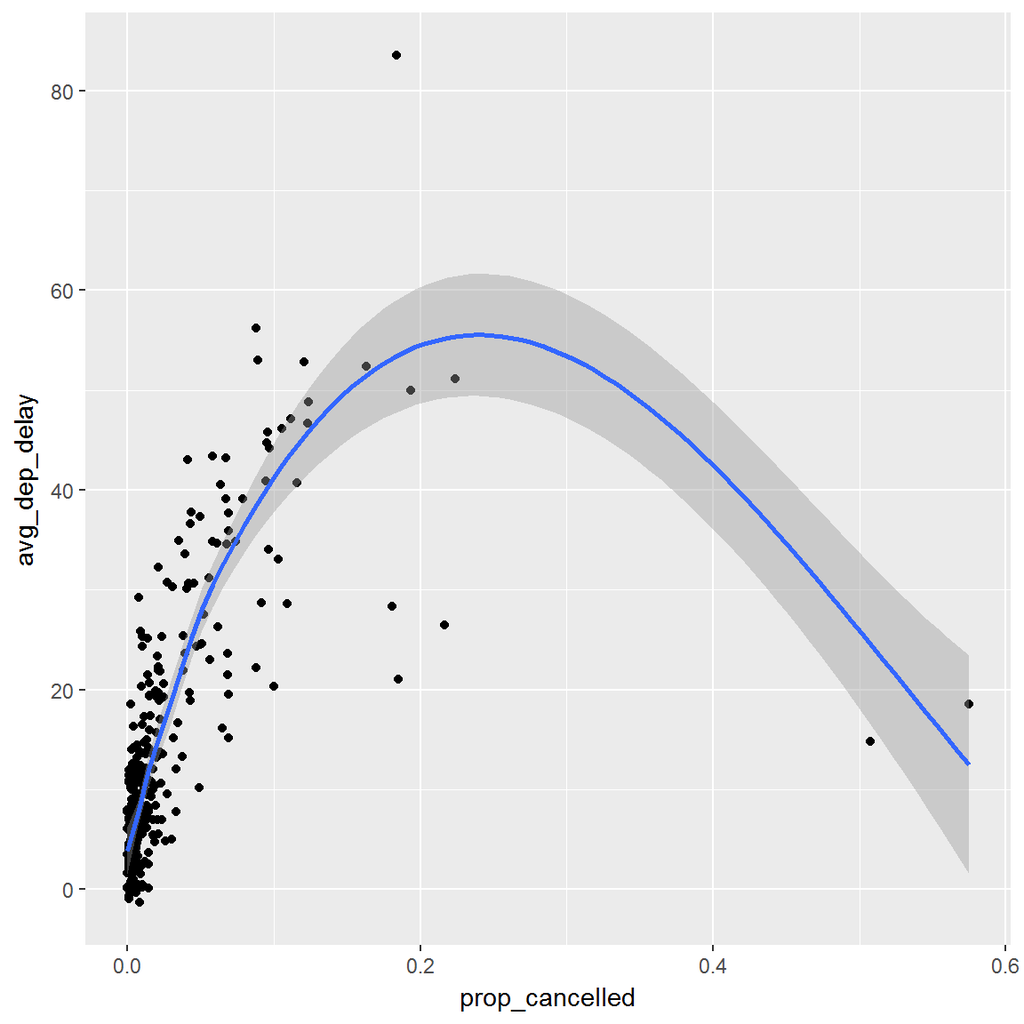

```r
flights %>%
  mutate(cancelled = is.na(dep_delay)) %>%
  group_by(month, day) %>%
  summarise(
    prop_cancelled = mean(cancelled),
    avg_dep_delay = mean(dep_delay, na.rm = TRUE)
  ) %>%
  ggplot(aes(x = prop_cancelled, y = avg_dep_delay)) +
    geom_point() +
    geom_smooth(se = TRUE)
```

There is a positive relationship between the proportion of cancelled flights and average delay. However, there are a few exceptional days with a high number of cancelled flights and relatively low average delay. If I had to guess, this might be related to bad weather (i.e., all flights were cancelled for a specific time period, so `avg_dep_delay` was close to zero).

5. Which carrier has the worst delays? Challenge: can you disentangle the effects of bad airports vs. bad carriers? Why/why not? (Hint: think about `flights %>% group_by(carrier, dest) %>% summarise(n())`)

Frontier Airlines (F9) has the worst delays:

```r
not_cancelled %>%
  group_by(carrier) %>%
  summarise(avg_delay = mean(dep_delay, na.rm = TRUE)) %>%
  arrange(desc(avg_delay))
```

```
## # A tibble: 16 x 2
##    carrier avg_delay
##      <chr>     <dbl>
##  1      F9 20.201175
##  2      EV 19.838929
##  3      YV 18.898897
##  4      FL 18.605984
##  5      WN 17.661657
##  6      9E 16.439574
##  7      B6 12.967548
##  8      VX 12.756646
##  9      OO 12.586207
## 10      UA 12.016908
## 11      MQ 10.445381
## 12      DL  9.223950
## 13      AA  8.569130
## 14      AS  5.830748
## 15      HA  4.900585
## 16      US  3.744693
```

You cannot disentangle the effects of bad airports vs. bad carriers because there is an uneven distribution in destinations by carrier. Some carriers might operate more frequently from bad airports and vice versa.

6. What does the `sort` argument to `count()` do. When might you use it?

`sort = TRUE` will sort output in descending order of `n`. You can use it for ranking instead of using `min_rank()` and/or `arrange()`.

```r
not_cancelled %>% count(dest, sort = TRUE)
```

```
## # A tibble: 104 x 2
##     dest     n
##    <chr> <int>
##  1   ATL 16837
##  2   ORD 16566
##  3   LAX 16026
##  4   BOS 15022
##  5   MCO 13967
##  6   CLT 13674
##  7   SFO 13173
##  8   FLL 11897
##  9   MIA 11593
## 10   DCA  9111
## # ... with 94 more rows
```

## 5.7.1 Exercises

1. Refer back to the lists of useful mutate and filtering functions. Describe how each operation changes when you combine it with grouping.

When combined with grouping, functions operate within groups only, not the entire dataset. For example:

```r
# What is the mean air time for each carrier?
flights %>%
  group_by(carrier) %>%
  summarise(mean_air_time = mean(air_time, na.rm = TRUE))
```

```
## # A tibble: 16 x 2
##    carrier mean_air_time
##      <chr>         <dbl>
##  1      9E      86.78160
##  2      AA     188.82230
##  3      AS     325.61777
##  4      B6     151.17717
##  5      DL     173.68880
##  6      EV      90.07619
##  7      F9     229.59912
##  8      FL     101.14394
##  9      HA     623.08772
## 10      MQ      91.18025
## 11      OO      83.48276
## 12      UA     211.79135
## 13      US      88.57380
## 14      VX     337.00235
## 15      WN     147.82481
## 16      YV      65.74081
```

```r
# What is the mean arrival delay for each month excluding all flights that were not delayed?
flights %>%
  filter(arr_delay > 0) %>%
  group_by(month) %>%
  summarise(avg_arr_delay = mean(arr_delay))
```

```
## # A tibble: 12 x 2
##    month avg_arr_delay
##    <int>         <dbl>
##  1     1      34.47749
##  2     2      33.68921
##  3     3      40.57166
##  4     4      42.73958
##  5     5      41.88586
##  6     6      53.73827
##  7     7      53.95152
##  8     8      39.51294
##  9     9      38.80555
## 10    10      29.03665
## 11    11      27.48459
## 12    12      39.72725
```

2. Which plane (`tailnum`) has the worst on-time record?

N844MH.

```r
flights %>%
  group_by(tailnum) %>%
  summarise(avg_delay = mean(arr_delay, na.rm = TRUE)) %>%
  arrange(desc(avg_delay))
```

```
## # A tibble: 4,044 x 2
##    tailnum avg_delay
##      <chr>     <dbl>
##  1  N844MH  320.0000
##  2  N911DA  294.0000
##  3  N922EV  276.0000
##  4  N587NW  264.0000
##  5  N851NW  219.0000
##  6  N928DN  201.0000
##  7  N7715E  188.0000
##  8  N654UA  185.0000
##  9  N665MQ  174.6667
## 10  N427SW  157.0000
## # ... with 4,034 more rows
```

3. What time of day should you fly if you want to avoid delays as much as possible?

Morning, preferably before 9 am.

```r
flights %>%
  group_by(hour) %>%
  summarise(avg_delay = mean(arr_delay, na.rm = TRUE)) %>%
  arrange(avg_delay)
```

```
## # A tibble: 20 x 2
##     hour  avg_delay
##    <dbl>      <dbl>
##  1     7 -5.3044716
##  2     5 -4.7969072
##  3     6 -3.3844854
##  4     9 -1.4514074
##  5     8 -1.1132266
##  6    10  0.9539401
##  7    11  1.4819300
##  8    12  3.4890104
##  9    13  6.5447397
## 10    14  9.1976501
## 11    23 11.7552783
## 12    15 12.3241920
## 13    16 12.5976412
## 14    18 14.7887244
## 15    22 15.9671618
## 16    17 16.0402670
## 17    19 16.6558736
## 18    20 16.6761098
## 19    21 18.3869371
## 20     1        NaN
```

4. For each destination, compute the total minutes of delay. For each, flight, compute the proportion of the total delay for its destination.

```r
flights %>%
  group_by(dest) %>%
  summarise(total_delay = sum(arr_delay, na.rm = TRUE))
```

```
## # A tibble: 105 x 2
##     dest total_delay
##    <chr>       <dbl>
##  1   ABQ        1113
##  2   ACK        1281
##  3   ALB        6018
##  4   ANC         -20
##  5   ATL      190260
##  6   AUS       14514
##  7   AVL        2089
##  8   BDL        2904
##  9   BGR        2874
## 10   BHM        4540
## # ... with 95 more rows
```

5. Delays are typically temporally correlated: even once the problem that caused the initial delay has been resolved, later flights are delayed to allow earlier flights to leave. Using `lag()` explore how the delay of a flight is related to the delay of the immediately preceding flight.

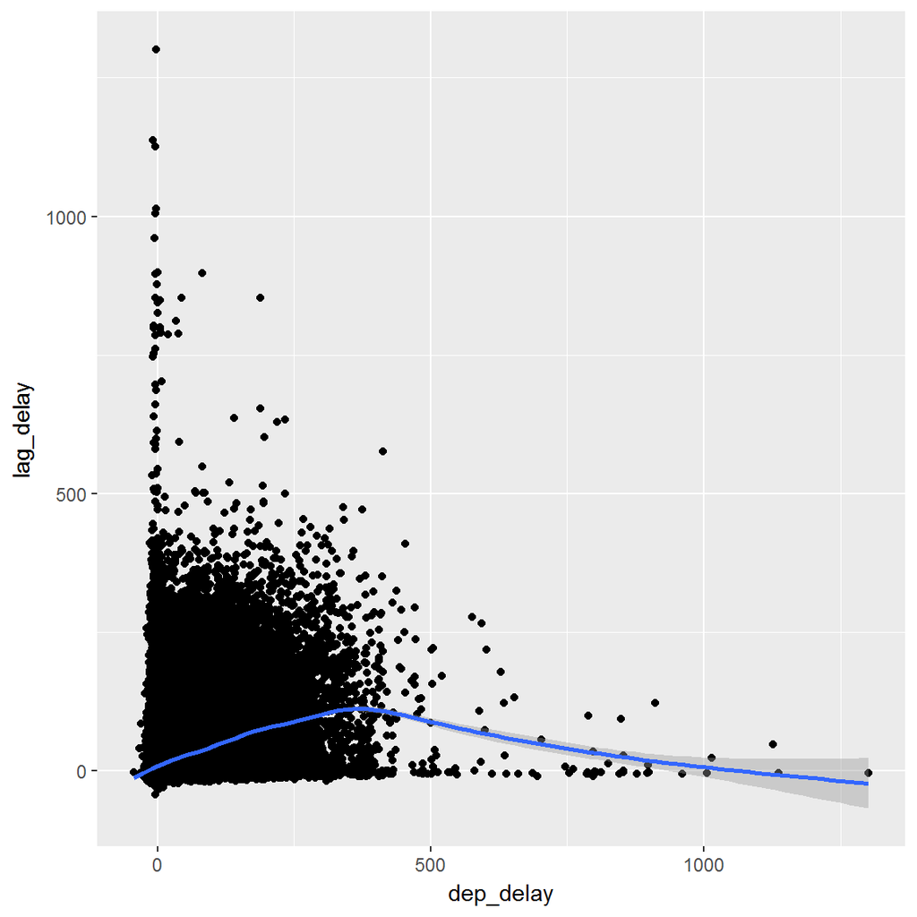

```r
flights %>%
  group_by(year, month, day) %>%
  mutate(lag_delay = lag(dep_delay)) %>%
  ggplot(aes(x = dep_delay, y = lag_delay)) +
    geom_point() +
    geom_smooth()
```

6. Look at each destination. Can you find flights that are suspiciously fast? (i.e. flights that represent a potential data entry error). Compute the air time a flight relative to the shortest flight to that destination. Which flights were most delayed in the air?
7. Find all destinations that are flown by at least two carriers. Use that information to rank the carriers.

```r
flights %>%
  group_by(dest, carrier) %>%
  count(carrier) %>%
  filter(carrier >= 2) %>%
  group_by(carrier) %>%
  count(sort = TRUE)
```

```
## # A tibble: 16 x 2
## # Groups:   carrier [16]
##    carrier    nn
##      <chr> <int>
##  1      EV    61
##  2      9E    49
##  3      UA    47
##  4      B6    42
##  5      DL    40
##  6      MQ    20
##  7      AA    19
##  8      WN    11
##  9      US     6
## 10      OO     5
## 11      VX     5
## 12      FL     3
## 13      YV     3
## 14      AS     1
## 15      F9     1
## 16      HA     1
```

8. For each plane, count the number of flights before the first delay of greater than 1 hour.

```r
flights %>%
  group_by(flight) %>%
  filter(dep_delay <= 60) %>%
  count()
```

```
## # A tibble: 3,810 x 2
## # Groups:   flight [3,810]
##    flight     n
##     <int> <int>
##  1      1   678
##  2      2    51
##  3      3   609
##  4      4   378
##  5      5   306
##  6      6   198
##  7      7   210
##  8      8   226
##  9      9   135
## 10     10    51
## # ... with 3,800 more rows
```

# 6. Workflow: scripts

## 6.3 Practice

1. Go to the RStudio Tips twitter account, https://twitter.com/rstudiotips and find one tip that looks interesting. Practice using it!

Ctrl + 1 (focus editor) and Ctrl + 2 (focus console) are my personal favourites.

2. What other common mistakes will RStudio diagnostics report? Read https://support.rstudio.com/hc/en-us/articles/205753617-Code-Diagnostics to find out.

Common mistakes such as:

- Warn if variable used has no definition in scope
- Warn if variable is defined but not used
- Style

Also, diagnostics for other languages such as C++, JavaScript, and Python.

# 10. Tibbles

## 10.5 Exercises

1. How can you tell if an object is a tibble? (Hint: try printing `mtcars`, which is a regular data frame).

`# A tibble:` is displayed in the top left of the output. Also, additional information is printed, such as column types and total number of rows and columns.

```r
as_tibble(mtcars)
```

```
## # A tibble: 32 x 11
##      mpg   cyl  disp    hp  drat    wt  qsec    vs    am  gear  carb
##  * <dbl> <dbl> <dbl> <dbl> <dbl> <dbl> <dbl> <dbl> <dbl> <dbl> <dbl>
##  1  21.0     6 160.0   110  3.90 2.620 16.46     0     1     4     4
##  2  21.0     6 160.0   110  3.90 2.875 17.02     0     1     4     4
##  3  22.8     4 108.0    93  3.85 2.320 18.61     1     1     4     1
##  4  21.4     6 258.0   110  3.08 3.215 19.44     1     0     3     1
##  5  18.7     8 360.0   175  3.15 3.440 17.02     0     0     3     2
##  6  18.1     6 225.0   105  2.76 3.460 20.22     1     0     3     1
##  7  14.3     8 360.0   245  3.21 3.570 15.84     0     0     3     4
##  8  24.4     4 146.7    62  3.69 3.190 20.00     1     0     4     2
##  9  22.8     4 140.8    95  3.92 3.150 22.90     1     0     4     2
## 10  19.2     6 167.6   123  3.92 3.440 18.30     1     0     4     4
## # ... with 22 more rows
```

2. Compare and contrast the following operations on a `data.frame` and equivalent tibble. What is different? Why might the default data frame behaviours cause you frustration?

   ```r
   df <- data.frame(abc = 1, xyz = "a")
   df$x
   df[, "xyz"]
   df[, c("abc", "xyz")]
   ```

```r
df <- tibble(abc = 1, xyz = "a")
df$x
```

```r
df[, "xyz"]
```

```
## # A tibble: 1 x 1
##     xyz
##   <chr>
## 1     a
```

```r
df[, c("abc", "xyz")]
```

```
## # A tibble: 1 x 2
##     abc   xyz
##   <dbl> <chr>
## 1     1     a
```

The default data frame uses partial matching. In comparison, tibbles do not. Data frames also store strings as factors by default.

```r
df <- data.frame(abc = 1, xyz = "a")
glimpse(df)
```

```
## Observations: 1
## Variables: 2
## $ abc <dbl> 1
## $ xyz <fctr> a
```

3. If you have the name of a variable stored in an object, e.g. `var <- "mpg"`, how can you extract the reference variable from a tibble?

By using the double bracket, `[[`. For example, `df[[var]]`.

4. Practice referring to non-syntactic names in the following data frame by:
   1. Extracting the variable called `1`.
   2. Plotting a scatterplot of `1` vs `2`.
   3. Creating a new column called `3` which is `2` divided by `1`.
   4. Renaming the columns to `one`, `two` and `three`.

   ```r
   annoying <- tibble(
     `1` = 1:10,
     `2` = `1` * 2 + rnorm(length(`1`))
   )
   ```

Extracting the variable called `1`:

```r
annoying$`1`
```

```
##  [1]  1  2  3  4  5  6  7  8  9 10
```

Plotting a scatterplot of `1` vs `2`:

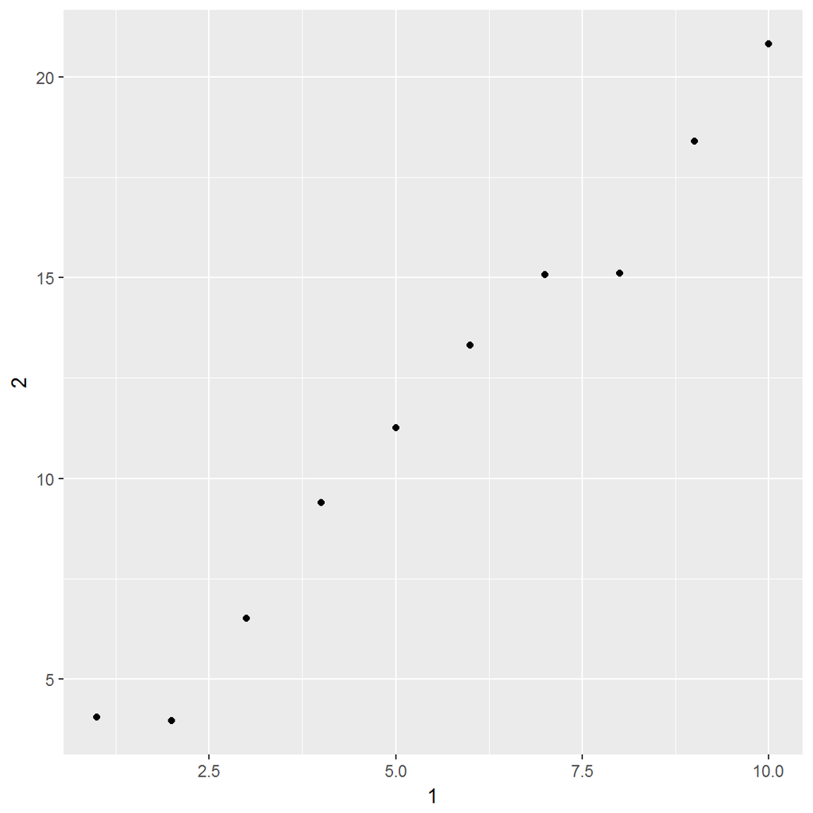

```r
ggplot(annoying, aes(`1`, `2`)) +
  geom_point()
```

Creating a new column called `3` which is `2` divided by `1`:

```r
annoying <- annoying %>%
  mutate(`3` = `2` / `1`)
```

Renaming the columns to `one`, `two` and `three`:

```r
annoying <- annoying %>%
  rename(`one` = `1`,
         `two` = `2`,
         `three` = `3`)
```

5. What does `tibble::enframe()` do? When might you use it?

It converts atomic vectors or lists to two-column data frames.

6. What option controls how many additional column names are printed at the footer of a tibble?

`n_extra` from `print.tbl()`. For example:

```r
print(flights, n_extra = 1)
```

```
## # A tibble: 336,776 x 19
##     year month   day dep_time sched_dep_time dep_delay arr_time
##    <int> <int> <int>    <int>          <int>     <dbl>    <int>
##  1  2013     1     1      517            515         2      830
##  2  2013     1     1      533            529         4      850
##  3  2013     1     1      542            540         2      923
##  4  2013     1     1      544            545        -1     1004
##  5  2013     1     1      554            600        -6      812
##  6  2013     1     1      554            558        -4      740
##  7  2013     1     1      555            600        -5      913
##  8  2013     1     1      557            600        -3      709
##  9  2013     1     1      557            600        -3      838
## 10  2013     1     1      558            600        -2      753
## # ... with 336,766 more rows, and 12 more variables: sched_arr_time <int>,
## #   ...
```

# 11. Data import

## 11.2.2 Exercises

1. What function would you use to read a file where fields were separated with  
   “|”?

`read_delim()`. The `delim` argument can be used to separate fields with “|”.

2. Apart from `file`, `skip`, and `comment`, what other arguments do `read_csv()` and `read_tsv()` have in common?

Some other arguments they have in common: `col_names`, `col_types`, `locale`, and `na`. In fact, it appears they share the exact same arguments.

3. What are the most important arguments to `read_fwf()`?

`widths`, `start`, and `end`.

4. Sometimes strings in a CSV file contain commas. To prevent them from causing problems they need to be surrounded by a quoting character, like `"` or `'`. By convention, `read_csv()` assumes that the quoting character will be `"`, and if you want to change it you’ll need to use `read_delim()` instead. What arguments do you need to specify to read the following text into a data frame?

   ```r
   "x,y\n1,'a,b'"
   ```

```r
x <- "x,y\n1,'a,b'"
df <- read_delim(x, ",", quote = "'")
```

5. Identify what is wrong with each of the following inline CSV files. What happens when you run the code?

   ```r
   read_csv("a,b\n1,2,3\n4,5,6")
   read_csv("a,b,c\n1,2\n1,2,3,4")
   read_csv("a,b\n\"1")
   read_csv("a,b\n1,2\na,b")
   read_csv("a;b\n1;3")
   ```

Let’s fix these:

```r
read_csv("a,b,c\n1,2,3\n4,5,6")
```

```
## # A tibble: 2 x 3
##       a     b     c
##   <int> <int> <int>
## 1     1     2     3
## 2     4     5     6
```

```r
read_csv("a,b,c\n1,2,1\n2,3,4")
```

```
## # A tibble: 2 x 3
##       a     b     c
##   <int> <int> <int>
## 1     1     2     1
## 2     2     3     4
```

```r
read_csv("a,b\n1")
```

```
## # A tibble: 1 x 2
##       a     b
##   <int> <chr>
## 1     1  <NA>
```

It’s unclear what the intent was here:

```r
read_csv("a,b\n1,2\na,b")
```

```
## # A tibble: 2 x 2
##       a     b
##   <chr> <chr>
## 1     1     2
## 2     a     b
```

```r
read_csv("a,b\n1,3")
```

```
## # A tibble: 1 x 2
##       a     b
##   <int> <int>
## 1     1     3
```

## 11.3.5 Exercises

1. What are the most important arguments to `locale()`?

`date_names` and maybe `decimal_mark`.

2. What happens if you try and set `decimal_mark` and `grouping_mark` to the same character? What happens to the default value of `grouping_mark` when you set `decimal_mark` to “,”? What happens to the default value of `decimal_mark` when you set the `grouping_mark` to “.”?

```r
locale(decimal_mark = ",", grouping_mark = ",")
```

```
## Error: `decimal_mark` and `grouping_mark` must be different
```

It produces an error.

```r
locale(decimal_mark = ",")
```

```
## <locale>
## Numbers:  123.456,78
## Formats:  %AD / %AT
## Timezone: UTC
## Encoding: UTF-8
## <date_names>
## Days:   Sunday (Sun), Monday (Mon), Tuesday (Tue), Wednesday (Wed),
##         Thursday (Thu), Friday (Fri), Saturday (Sat)
## Months: January (Jan), February (Feb), March (Mar), April (Apr), May
##         (May), June (Jun), July (Jul), August (Aug), September
##         (Sep), October (Oct), November (Nov), December (Dec)
## AM/PM:  AM/PM
```

The default value for `grouping_mark` is changed to “.”.

```r
locale(grouping_mark = ".")
```

```
## <locale>
## Numbers:  123.456,78
## Formats:  %AD / %AT
## Timezone: UTC
## Encoding: UTF-8
## <date_names>
## Days:   Sunday (Sun), Monday (Mon), Tuesday (Tue), Wednesday (Wed),
##         Thursday (Thu), Friday (Fri), Saturday (Sat)
## Months: January (Jan), February (Feb), March (Mar), April (Apr), May
##         (May), June (Jun), July (Jul), August (Aug), September
##         (Sep), October (Oct), November (Nov), December (Dec)
## AM/PM:  AM/PM
```

The default value for `decimal_mark` is changed to “,”.

3. I didn’t discuss the `date_format` and `time_format` options to `locale()`. What do they do? Construct an example that shows when they might be useful.

`date_format` and `time_format` allows you to specify the default date and time formats.

```r
str(parse_guess("01/13/2018", locale = locale(date_format = "%m/%d/%Y")))
```

```
##  Date[1:1], format: "2018-01-13"
```

According to `vignette("readr")`, `time_format` isn’t currently used for anything.

4. If you live outside the US, create a new locale object that encapsulates the settings for the types of file you read most commonly.

```r
locale(date_names = "en", date_format = "%d/%m/%Y", decimal_mark = ".",
       grouping_mark = ",", tz = "Australia/Perth")
```

```
## <locale>
## Numbers:  123,456.78
## Formats:  %d/%m/%Y / %AT
## Timezone: Australia/Perth
## Encoding: UTF-8
## <date_names>
## Days:   Sunday (Sun), Monday (Mon), Tuesday (Tue), Wednesday (Wed),
##         Thursday (Thu), Friday (Fri), Saturday (Sat)
## Months: January (Jan), February (Feb), March (Mar), April (Apr), May
##         (May), June (Jun), July (Jul), August (Aug), September
##         (Sep), October (Oct), November (Nov), December (Dec)
## AM/PM:  AM/PM
```

5. What’s the difference between `read_csv()` and `read_csv2()`?

`read_csv2` uses “;” (i.e., a semi-colon) for separators instead of “,” (a comma).

6. What are the most common encodings used in Europe? What are the most common encodings used in Asia? Do some googling to find out.

UTF-8 is the standard worldwide. In Europe, ISO 8859-1 is a common encoding. Shift JIS is a common encoding in Asia.

7. Generate the correct format string to parse each of the following dates and times:

```r
d1 <- "January 1, 2010"
d2 <- "2015-Mar-07"
d3 <- "06-Jun-2017"
d4 <- c("August 19 (2015)", "July 1 (2015)")
d5 <- "12/30/14" # Dec 30, 2014
t1 <- "1705"
t2 <- "11:15:10.12 PM"
```

```r
str(parse_date(d1, format = "%B %d, %Y"))
```

```
##  Date[1:1], format: "2010-01-01"
```

```r
str(parse_date(d2, format = "%Y-%b-%d"))
```

```
##  Date[1:1], format: "2015-03-07"
```

```r
str(parse_date(d3, format = "%d-%b-%Y"))
```

```
##  Date[1:1], format: "2017-06-06"
```

```r
str(parse_date(d4, format = "%B %d (%Y)"))
```

```
##  Date[1:2], format: "2015-08-19" "2015-07-01"
```

```r
str(parse_date(d5, format = "%m/%d/%y"))
```

```
##  Date[1:1], format: "2014-12-30"
```

```r
str(parse_time(t1, format = "%H%M"))
```

```
## Classes 'hms', 'difftime'  atomic [1:1] 61500
##   ..- attr(*, "units")= chr "secs"
```

```r
str(parse_time(t2, format = "%H:%M:%OS %p"))
```

```
## Classes 'hms', 'difftime'  atomic [1:1] 83710
##   ..- attr(*, "units")= chr "secs"
```

# 12. Tidy data

## 12.2.1 Exercises

1. Using prose, describe how the variables and observations are organised in each of the sample tables.

In `table1`, each variable has its own column, each observation its own row, and each value its own cell. Therefore, `table1` is a tidy dataset.

In `table2` the `cases` and `population` do not have their own columns, but rather, are treated as values. `table3` does not have the `cases` and `population` variables stored separately. Instead, both are stored as part of a calculation under `rate`. `table4a` stores the values of the `year` variable as separate variables (with their own columns), with the values being the number of cases (population is missing). `table 4b` is similar, but uses `population` for the values rather than `cases`.

2. Compute the `rate` for `table2`, and `table4a` + `table4b`. You will need to perform four operations:
   1. Extract the number of TB cases per country per year.
   2. Extract the matching population per country per year.
   3. Divide cases by population, and multiply by 10000.
   4. Store back in the appropriate place.

   Which representation is easiest to work with? Which is hardest? Why?

Extract the number of TB cases per country per year:

```r
table2_cases <- filter(table2, type == "cases")[["count"]]
```

Extract the matching population per country per year:

```r
table2_population <- filter(table2, type == "population")[["count"]]
```

Divide cases by population, and multiply by 10000:

```r
table2_rate <- table2_cases / table2_population * 10000
```

Store back in the appropriate place:

```r
table2_country <- filter(table2, type == "cases")[["country"]]
table2_year <- filter(table2, type == "cases")[["year"]]

table2_new <- tibble(
  country = table2_country,
  year = table2_year,
  cases = table2_cases,
  population = table2_population,
  rate = table2_rate
  )
table2_new
```

```
## # A tibble: 6 x 5
##       country  year  cases population     rate
##         <chr> <int>  <int>      <int>    <dbl>
## 1 Afghanistan  1999    745   19987071 0.372741
## 2 Afghanistan  2000   2666   20595360 1.294466
## 3      Brazil  1999  37737  172006362 2.193930
## 4      Brazil  2000  80488  174504898 4.612363
## 5       China  1999 212258 1272915272 1.667495
## 6       China  2000 213766 1280428583 1.669488
```

For `table4a` and `table4b`:

```r
table4_new <- tibble(
  country = table4a[["country"]],
  `1999` = table4a[["1999"]] / table4b[["1999"]] * 10000,
  `2000` = table4a[["2000"]] / table4b[["2000"]] * 10000
  )
table4_new
```

```
## # A tibble: 3 x 3
##       country   `1999`   `2000`
##         <chr>    <dbl>    <dbl>
## 1 Afghanistan 0.372741 1.294466
## 2      Brazil 2.193930 4.612363
## 3       China 1.667495 1.669488
```

3. Recreate the plot showing change in cases over time using `table2` instead of `table1`. What do you need to do first?

Filter `cases`:

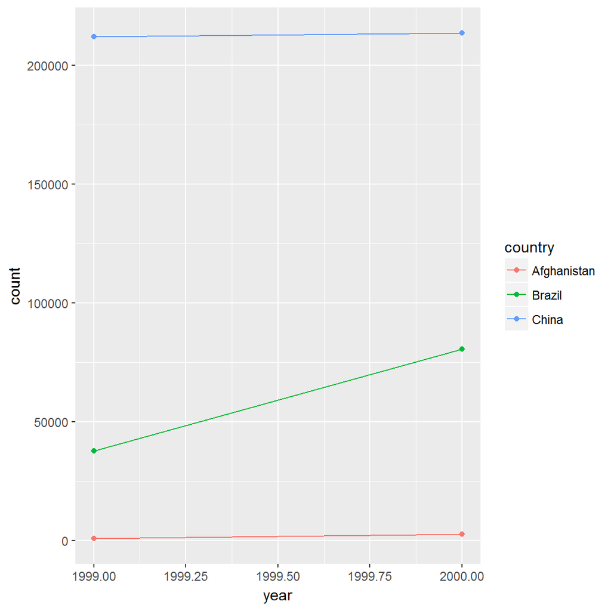

```r
table2 %>%
  filter(type == "cases") %>%
  ggplot(aes(year, count, group = country, colour = country)) +
    geom_line() +
    geom_point()
```

## 12.3.3 Exercises

1. Why are `gather()` and `spread()` not perfectly symmetrical?  
   Carefully consider the following example:

   ```r
   stocks <- tibble(
     year   = c(2015, 2015, 2016, 2016),
     half  = c(   1,    2,     1,    2),
     return = c(1.88, 0.59, 0.92, 0.17)
   )
   stocks %>%
     spread(year, return) %>%
     gather("year", "return", `2015`:`2016`)
   ```

   (Hint: look at the variable types and think about column *names*.)

   Both `spread()` and `gather()` have a `convert` argument. What does it do?

`gather()` and `spread()` are not perfectly symmetrical because variable type is not retained when using both functions, as seen in the example above. In `stocks`, `year` is numeric:

```r
stocks %>% select(year)
```

```
## # A tibble: 4 x 1
##    year
##   <dbl>
## 1  2015
## 2  2015
## 3  2016
## 4  2016
```

However, after using the `spread()` and `gather()` functions it becomes `character`:

```r
stocks %>%
  spread(year, return) %>%
  gather("year", "return", `2015`:`2016`) %>%
  select(year)
```

```
## # A tibble: 4 x 1
##    year
##   <chr>
## 1  2015
## 2  2015
## 3  2016
## 4  2016
```

The `convert` argument, when set to `TRUE`, will retain numeric, integer, or logical column types when using `spread()` or `gather()`.

2. Why does this code fail?

   ```r
   table4a %>%
     gather(1999, 2000, key = "year", value = "cases")
   ```

   ```
   ## Error in inds_combine(.vars, ind_list): Position must be between 0 and n
   ```

“1999” and “2000” are non-syntactic names so they have to be surrounded by backticks.

```r
table4a %>%
  gather(`1999`, `2000`, key = "year", value = "cases")
```

```
## # A tibble: 6 x 3
##       country  year  cases
##         <chr> <chr>  <int>
## 1 Afghanistan  1999    745
## 2      Brazil  1999  37737
## 3       China  1999 212258
## 4 Afghanistan  2000   2666
## 5      Brazil  2000  80488
## 6       China  2000 213766
```

3. Why does spreading this tibble fail? How could you add a new column to fix the problem?

   ```r
   people <- tribble(
     ~name,             ~key,    ~value,
     #-----------------|--------|------
     "Phillip Woods",   "age",       45,
     "Phillip Woods",   "height",   186,
     "Phillip Woods",   "age",       50,
     "Jessica Cordero", "age",       37,
     "Jessica Cordero", "height",   156
   )
   ```

```r
people %>% spread(key, value)
```

```
## Error: Duplicate identifiers for rows (1, 3)
```

Phillip Woods’ age has been entered twice. You could add a new column that indicates the time of observation:

```r
people <- tribble(
  ~name,             ~key,    ~value, ~time,
  #-----------------|--------|------|-------
  "Phillip Woods",   "age",       45, 1,
  "Phillip Woods",   "height",   186, 1,
  "Phillip Woods",   "age",       50, 2,
  "Jessica Cordero", "age",       37, 1,
  "Jessica Cordero", "height",   156, 1
)
```

```r
people %>% spread(key, value)
```

```
## # A tibble: 3 x 4
##              name  time   age height
## *           <chr> <dbl> <dbl>  <dbl>
## 1 Jessica Cordero     1    37    156
## 2   Phillip Woods     1    45    186
## 3   Phillip Woods     2    50     NA
```

4. Tidy the simple tibble below. Do you need to spread or gather it? What are the variables?

   ```r
   preg <- tribble(
     ~pregnant, ~male, ~female,
     "yes",     NA,    10,
     "no",      20,    12
   )
   ```

It needs to be gathered. The variables are sex (male or female) and pregnant (yes or no).

```r
preg %>% gather(
  male, female,
  key = "sex",
  value = "count"
)
```

```
## # A tibble: 4 x 3
##   pregnant    sex count
##      <chr>  <chr> <dbl>
## 1      yes   male    NA
## 2       no   male    20
## 3      yes female    10
## 4       no female    12
```

## 12.4.3 Exercises

1. What do the `extra` and `fill` arguments do in `separate()`? Experiment with the various options for the following two toy datasets.

   ```r
   tibble(x = c("a,b,c", "d,e,f,g", "h,i,j")) %>%
     separate(x, c("one", "two", "three"))

   tibble(x = c("a,b,c", "d,e", "f,g,i")) %>%
     separate(x, c("one", "two", "three"))
   ```

`extra` controls what happens when you use a character vector in `sep` and there are too many pieces.

```r
tibble(x = c("a,b,c", "d,e,f,g", "h,i,j")) %>%
  separate(x, c("one", "two", "three"), extra = "merge")
```

```
## # A tibble: 3 x 3
##     one   two three
## * <chr> <chr> <chr>
## 1     a     b     c
## 2     d     e   f,g
## 3     h     i     j
```

In comparison, `fill` controls what happens when there are not enough pieces.

```r
tibble(x = c("a,b,c", "d,e", "f,g,i")) %>%
  separate(x, c("one", "two", "three"), fill = "left")
```

```
## # A tibble: 3 x 3
##     one   two three
## * <chr> <chr> <chr>
## 1     a     b     c
## 2  <NA>     d     e
## 3     f     g     i
```

2. Both `unite()` and `separate()` have a `remove` argument. What does it do? Why would you set it to `FALSE`?

It removes the input column from the data frame. By setting this to `FALSE`, you can retain the original input column in the dataset:

```r
tibble(x = c("a,b,c", "d,e,f", "g,h,i")) %>%
  separate(x, c("one", "two", "three"), remove = "FALSE")
```

```
## # A tibble: 3 x 4
##       x   one   two three
## * <chr> <chr> <chr> <chr>
## 1 a,b,c     a     b     c
## 2 d,e,f     d     e     f
## 3 g,h,i     g     h     i
```

3. Compare and contrast `separate()` and `extract()`. Why are there three variations of separation (by position, by separator, and with groups), but only one unite?

```r
tibble(x = c("a,b,c", "d,e,f", "g,h,i")) %>%
  separate(x, c("one", "two", "three"))
```

```
## # A tibble: 3 x 3
##     one   two three
## * <chr> <chr> <chr>
## 1     a     b     c
## 2     d     e     f
## 3     g     h     i
```

```r
tibble(x = c("a,b,c", "d,e,f", "g,h,i"))
```

```
## # A tibble: 3 x 1
##       x
##   <chr>
## 1 a,b,c
## 2 d,e,f
## 3 g,h,i
```

```r
tibble(x = c("a,b,c", "d,e,f", "g,h,i")) %>%
  extract(x, "A")
```

```
## # A tibble: 3 x 1
##       A
## * <chr>
## 1     a
## 2     d
## 3     g
```

`separate()` pulls apart one column and places the values into many columns. `extract()` is a similar function, but, as its name implies, only retains values you wish to extract from a data frame.

`unite()` only requires one variation of separation because it is combining multiple columns into one column. Therefore, there is only one way to do it (using `sep`). In comparison, there are multiple ways to split a character string for `separate()` (e.g., by position or by separator).

## 12.5.1 Exercises

1. Compare and contrast the `fill` arguments to `spread()` and `complete()`.

For `spread()`, `fill` will replace missing values in a data set with this value. In comparison, the `fill` argument for `complete()` allows you to replace missing values by column name.

2. What does the direction argument to `fill()` do?

It is the direction in which to fill missing values. For example:

```r
df <- data.frame(Month = 1:12, Year = c(NA, 2000, rep(NA, 10)))
df %>% fill(Year, .direction = c("up"))
```

```
##    Month Year
## 1      1 2000
## 2      2 2000
## 3      3   NA
## 4      4   NA
## 5      5   NA
## 6      6   NA
## 7      7   NA
## 8      8   NA
## 9      9   NA
## 10    10   NA
## 11    11   NA
## 12    12   NA
```

## 12.6.1 Exercises

1. In this case study I set `na.rm = TRUE` just to make it easier to check that we had the correct values. Is this reasonable? Think about how missing values are represented in this dataset. Are there implicit missing values? What’s the difference between an `NA` and zero?

I think this is reasonable. Missing values appear to be represented explicitely in this dataset:

```r
who %>%
  gather(new_sp_m014:newrel_f65, key = "key", value = "cases") %>%
  count(is.na(cases))
```

```
## # A tibble: 2 x 2
##   `is.na(cases)`      n
##            <lgl>  <int>
## 1          FALSE  76046
## 2           TRUE 329394
```

It is difficult to determine whether there are implicit missing values in a dataset because, as stated earlier in the chapter, implicit missing values are an “absence of a presence”.

`NA` indicates an explicit missing value. So, the number of actual cases for an `NA` observation is not necessarily zero. In comparison, a value of zero indicates there were no cases for a particular observation.

```r
who %>%
  gather(new_sp_m014:newrel_f65, key = "key", value = "cases") %>%
  filter(cases == 0) %>%
  nrow()
```

```
## [1] 11080
```

2. What happens if you neglect the `mutate()` step? (`mutate(key = stringr::str_replace(key, "newrel", "new_rel"))`)

```r
who %>%
  gather(code, value, new_sp_m014:newrel_f65, na.rm = TRUE) %>%
  separate(code, c("new", "var", "sexage")) %>%
  select(-new, -iso2, -iso3) %>%
  separate(sexage, c("sex", "age"), sep = 1)
```

```
## # A tibble: 76,046 x 6
##        country  year   var   sex   age value
##  *       <chr> <int> <chr> <chr> <chr> <int>
##  1 Afghanistan  1997    sp     m   014     0
##  2 Afghanistan  1998    sp     m   014    30
##  3 Afghanistan  1999    sp     m   014     8
##  4 Afghanistan  2000    sp     m   014    52
##  5 Afghanistan  2001    sp     m   014   129
##  6 Afghanistan  2002    sp     m   014    90
##  7 Afghanistan  2003    sp     m   014   127
##  8 Afghanistan  2004    sp     m   014   139
##  9 Afghanistan  2005    sp     m   014   151
## 10 Afghanistan  2006    sp     m   014   193
## # ... with 76,036 more rows
```

It won’t split the string `newrel` properly.

```r
split_problem <- who %>%
  gather(code, value, new_sp_m014:newrel_f65, na.rm = TRUE) %>%
  separate(code, c("new", "var", "sexage")) %>%
  select(-new, -iso2, -iso3) %>%
  separate(sexage, c("sex", "age"), sep = 1)
split_problem %>% slice(73467:73486)
```

```
## # A tibble: 20 x 6
##                country  year   var   sex   age value
##                  <chr> <int> <chr> <chr> <chr> <int>
##  1         Afghanistan  2013  m014  <NA>  <NA>  1705
##  2             Albania  2013  m014  <NA>  <NA>    14
##  3             Algeria  2013  m014  <NA>  <NA>    25
##  4             Andorra  2013  m014  <NA>  <NA>     0
##  5              Angola  2013  m014  <NA>  <NA>   486
##  6            Anguilla  2013  m014  <NA>  <NA>     0
##  7 Antigua and Barbuda  2013  m014  <NA>  <NA>     1
##  8           Argentina  2013  m014  <NA>  <NA>   462
##  9             Armenia  2013  m014  <NA>  <NA>    25
## 10           Australia  2013  m014  <NA>  <NA>    28
## 11             Austria  2013  m014  <NA>  <NA>    15
## 12          Azerbaijan  2013  m014  <NA>  <NA>   125
## 13             Bahamas  2013  m014  <NA>  <NA>     3
## 14             Bahrain  2013  m014  <NA>  <NA>     4
## 15          Bangladesh  2013  m014  <NA>  <NA>  2323
## 16            Barbados  2013  m014  <NA>  <NA>     0
## 17             Belarus  2013  m014  <NA>  <NA>     4
## 18             Belgium  2013  m014  <NA>  <NA>    40
## 19              Belize  2013  m014  <NA>  <NA>     1
## 20               Benin  2013  m014  <NA>  <NA>    25
```

For relapse cases, gender and age group have not separated (they appear under `var`), and `sex` and `age` variables are `NA`.

3. I claimed that `iso2` and `iso3` were redundant with `country`. Confirm this claim.

For each country, there is only one unique combination of `iso2` and `iso3`:

```r
who %>%
  gather(new_sp_m014:newrel_f65, key = "key", value = "cases", na.rm = TRUE) %>%
  select(country, iso2, iso3) %>%
  distinct() %>%
  group_by(country) %>%
  filter(n() > 1)
```

```
## # A tibble: 0 x 3
## # Groups:   country [0]
## # ... with 3 variables: country <chr>, iso2 <chr>, iso3 <chr>
```

4. For each country, year, and sex compute the total number of cases of TB. Make an informative visualisation of the data.

```r
who_cases <- who %>%
  gather(code, value, new_sp_m014:newrel_f65, na.rm = TRUE) %>%
  mutate(code = stringr::str_replace(code, "newrel", "new_rel")) %>%
  separate(code, c("new", "var", "sexage")) %>%
  select(-new, -iso2, -iso3) %>%
  separate(sexage, c("sex", "age"), sep = 1) %>%
  group_by(country, year, sex) %>%
  summarise(cases = sum(value))

who_cases
```

```
## # A tibble: 6,921 x 4
## # Groups:   country, year [?]
##        country  year   sex cases
##          <chr> <int> <chr> <int>
##  1 Afghanistan  1997     f   102
##  2 Afghanistan  1997     m    26
##  3 Afghanistan  1998     f  1207
##  4 Afghanistan  1998     m   571
##  5 Afghanistan  1999     f   517
##  6 Afghanistan  1999     m   228
##  7 Afghanistan  2000     f  1751
##  8 Afghanistan  2000     m   915
##  9 Afghanistan  2001     f  3062
## 10 Afghanistan  2001     m  1577
## # ... with 6,911 more rows
```

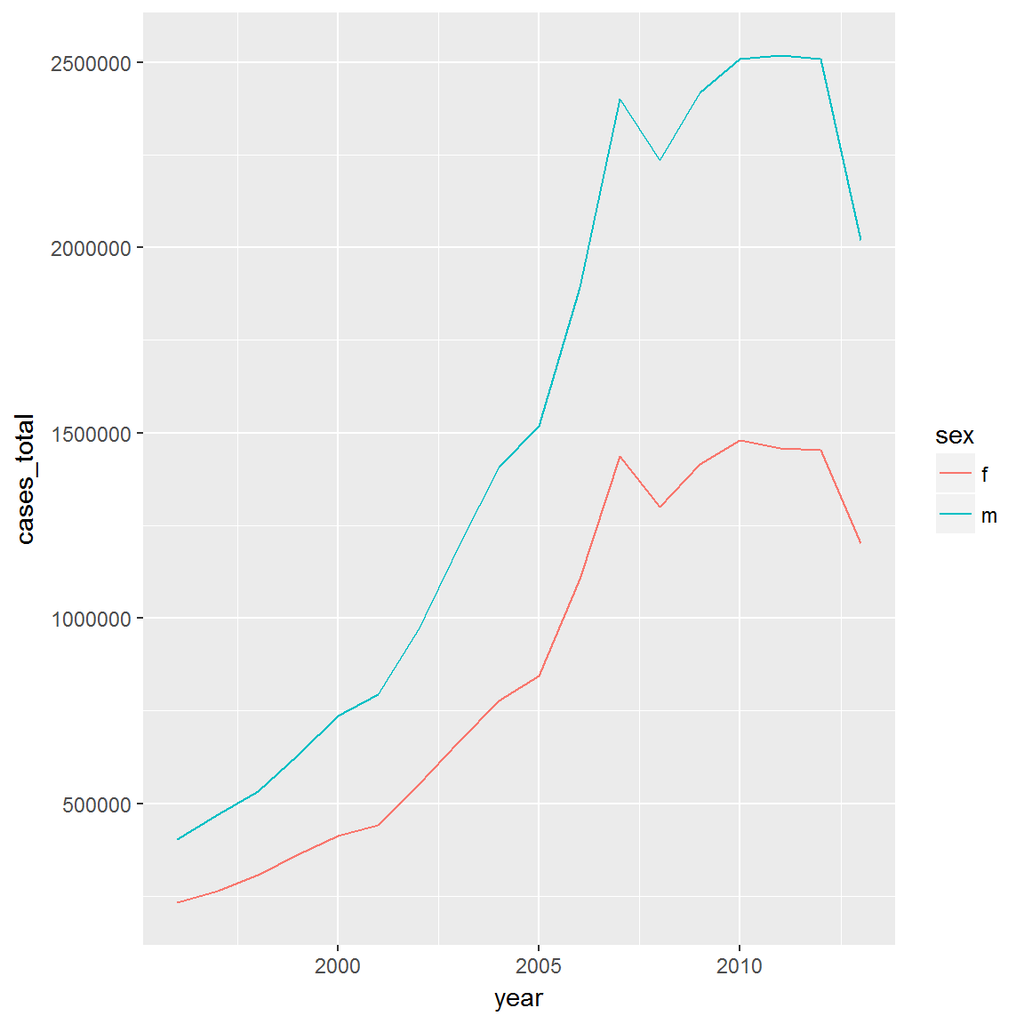

```r
who_cases %>%
  group_by(sex, year) %>%
  filter(year > 1995) %>%
  summarise(cases_total = sum(cases)) %>%
  ggplot(aes(x = year, y = cases_total, group = sex, colour = sex)) +
    geom_line()
```

# 13. Relational data

## 13.2.1 Exercises

1. Imagine you wanted to draw (approximately) the route each plane flies from its origin to its destination. What variables would you need? What tables would you need to combine?

From `flights`, you would need `origin` and `dest`. From `airports`, `lat`, `lon` (the locations of the airport), and maybe `alt` would be required. You would need to combine the `flights` and `airports` tables to get the origin airport and destination airport.

The `weather` table may also be helpful as wind speed, wind direction, and visibility may affect the route.

2. I forgot to draw the relationship between `weather` and `airports`. What is the relationship and how should it appear in the diagram?

`weather` connects to `airports` via `origin` (the location). In the diagram, there should be an arrow pointing from `faa` in the `airports` table to `origin` in the `weather` table.

3. `weather` only contains information for the origin (NYC) airports. If it contained weather records for all airports in the USA, what additional relation would it define with `flights`?

`year`, `month`, `day`, and `hour`.

4. We know that some days of the year are “special”, and fewer people than usual fly on them. How might you represent that data as a data frame? What would be the primary keys of that table? How would it connect to the existing tables?

You would have date and name variables. The primary key of this table would be date. It would match to `year`, `month`, and `day` in other tables such as `flights`.

## 13.3.1 Exercises

1. Add a surrogate key to `flights`.

```r
flights %>%
  arrange(year, month, day, sched_dep_time) %>%
  mutate(flight_id = row_number())
```

```
## # A tibble: 336,776 x 20
##     year month   day dep_time sched_dep_time dep_delay arr_time
##    <int> <int> <int>    <int>          <int>     <dbl>    <int>
##  1  2013     1     1      517            515         2      830
##  2  2013     1     1      533            529         4      850
##  3  2013     1     1      542            540         2      923
##  4  2013     1     1      544            545        -1     1004
##  5  2013     1     1      554            558        -4      740
##  6  2013     1     1      559            559         0      702
##  7  2013     1     1      554            600        -6      812
##  8  2013     1     1      555            600        -5      913
##  9  2013     1     1      557            600        -3      709
## 10  2013     1     1      557            600        -3      838
## # ... with 336,766 more rows, and 13 more variables: sched_arr_time <int>,
## #   arr_delay <dbl>, carrier <chr>, flight <int>, tailnum <chr>,
## #   origin <chr>, dest <chr>, air_time <dbl>, distance <dbl>, hour <dbl>,
## #   minute <dbl>, time_hour <dttm>, flight_id <int>
```

2. Identify the keys in the following datasets
   1. `Lahman::Batting`,
   2. `babynames::babynames`
   3. `nasaweather::atmos`
   4. `fueleconomy::vehicles`
   5. `ggplot2::diamonds`

   (You might need to install some packages and read some documentation.)

`Lahman::Batting`:

The primary keys for `Lahman::Batting` are `playerID`, `yearID`, and `stint`.

```r
Lahman::Batting %>%
  count(playerID, yearID, stint) %>%
  filter(n > 1)
```

```
## # A tibble: 0 x 4
## # ... with 4 variables: playerID <chr>, yearID <int>, stint <int>, n <int>
```

`playerID` is a foreign key (it is the primary key for `Lahman::Master`).

`babynames::babynames`:

The primary keys for `babynames::babynames` are `year`, `sex`, and `name`.

```r
babynames::babynames %>%
  group_by(year, sex, name) %>%
  filter(n() > 1)
```

```
## # A tibble: 0 x 5
## # Groups:   year, sex, name [0]
## # ... with 5 variables: year <dbl>, sex <chr>, name <chr>, n <int>,
## #   prop <dbl>
```

`nasaweather::atmos`:

For `nasaweather:atmos`, the primary keys are `lat`, `long`, `year`, and `month`.

```r
nasaweather::atmos %>%
  group_by(lat, long, year, month) %>%
  filter(n() > 1)
```

```
## # A tibble: 0 x 11
## # Groups:   lat, long, year, month [0]
## # ... with 11 variables: lat <dbl>, long <dbl>, year <int>, month <int>,
## #   surftemp <dbl>, temp <dbl>, pressure <dbl>, ozone <dbl>,
## #   cloudlow <dbl>, cloudmid <dbl>, cloudhigh <dbl>
```

`fueleconomy::vehicles`:

The primary key for `fueleconomy::vehicles` is `id`.

```r
fueleconomy::vehicles %>%
  count(id) %>%
  filter(n > 1)
```

```
## # A tibble: 0 x 2
## # ... with 2 variables: id <int>, n <int>
```

`ggplot2::diamonds`:

`ggplot2::diamonds` does not appear to have a primary key.

```r
ggplot2::diamonds %>%
  group_by(carat, cut, color, clarity, depth, table, price, x, y, z) %>%
  filter(n() > 1) %>%
  nrow()
```

```
## [1] 289
```

3. Draw a diagram illustrating the connections between the `Batting`, `Master`, and `Salaries` tables in the Lahman package. Draw another diagram that shows the relationship between `Master`, `Managers`, `AwardsManagers`.

   How would you characterise the relationship between the `Batting`, `Pitching`, and `Fielding` tables?

## 13.4.6 Exercises

1. Compute the average delay by destination, then join on the `airports` data frame so you can show the spatial distribution of delays. Here’s an easy way to draw a map of the United States:

   ```r
   airports %>%
     semi_join(flights, c("faa" = "dest")) %>%
     ggplot(aes(lon, lat)) +
       borders("state") +
       geom_point() +
       coord_quickmap()
   ```

   (Don’t worry if you don’t understand what `semi_join()` does — you’ll learn about it next.)

   You might want to use the `size` or `colour` of the points to display the average delay for each airport.

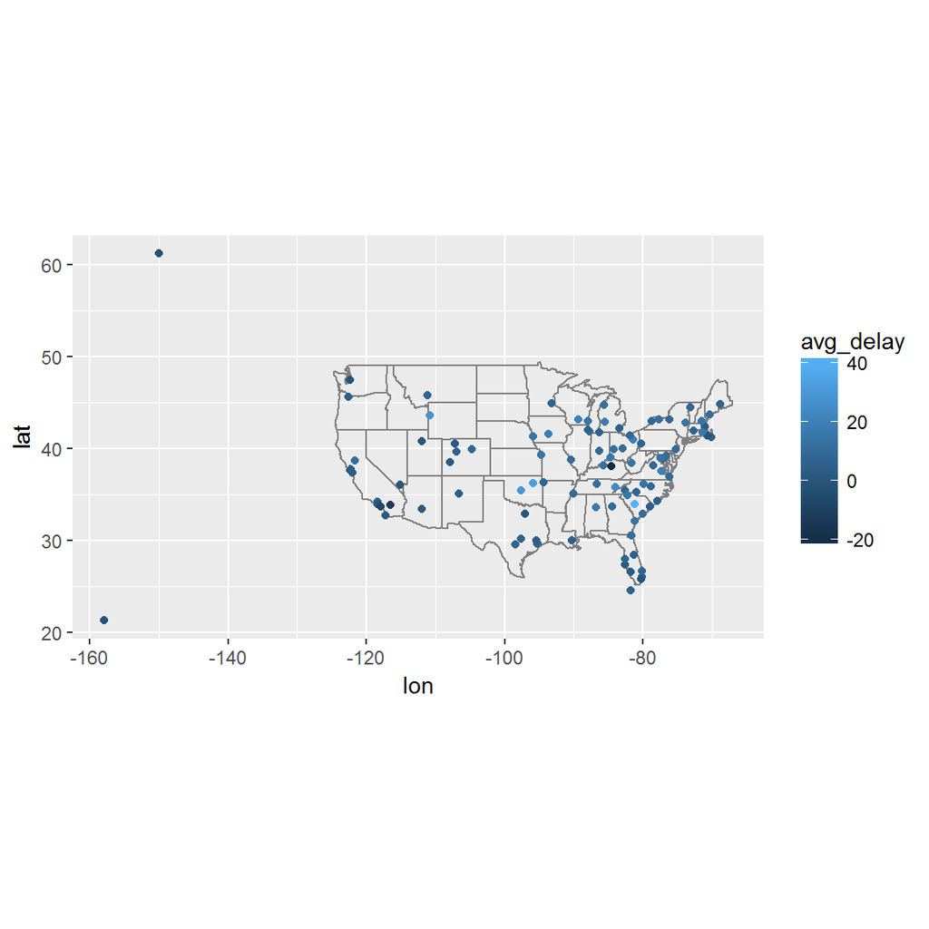

```r
dest_delay <- flights %>%
  group_by(dest) %>%
  summarise(avg_delay = mean(arr_delay, na.rm = TRUE))

dest_delay %>%
  left_join(airports, c("dest" = "faa")) %>%
  ggplot(aes(lon, lat)) +
    borders("state") +
    geom_point(aes(colour = avg_delay)) +
    coord_quickmap()
```

2. Add the location of the origin *and* destination (i.e. the `lat` and `lon`) to `flights`.

```r
flights %>%
  left_join(airports, c("origin" = "faa")) %>%
  left_join(airports, c("dest" = "faa")) %>%
  rename(lat_origin = lat.x, lon_origin = lon.x) %>%
  rename(lat_dest = lat.y, lon_dest = lon.y) %>%
  select(-contains("."))
```

```
## # A tibble: 336,776 x 23
##     year month   day dep_time sched_dep_time dep_delay arr_time
##    <int> <int> <int>    <int>          <int>     <dbl>    <int>
##  1  2013     1     1      517            515         2      830
##  2  2013     1     1      533            529         4      850
##  3  2013     1     1      542            540         2      923
##  4  2013     1     1      544            545        -1     1004
##  5  2013     1     1      554            600        -6      812
##  6  2013     1     1      554            558        -4      740
##  7  2013     1     1      555            600        -5      913
##  8  2013     1     1      557            600        -3      709
##  9  2013     1     1      557            600        -3      838
## 10  2013     1     1      558            600        -2      753
## # ... with 336,766 more rows, and 16 more variables: sched_arr_time <int>,
## #   arr_delay <dbl>, carrier <chr>, flight <int>, tailnum <chr>,
## #   origin <chr>, dest <chr>, air_time <dbl>, distance <dbl>, hour <dbl>,
## #   minute <dbl>, time_hour <dttm>, lat_origin <dbl>, lon_origin <dbl>,
## #   lat_dest <dbl>, lon_dest <dbl>
```

3. Is there a relationship between the age of a plane and its delays?

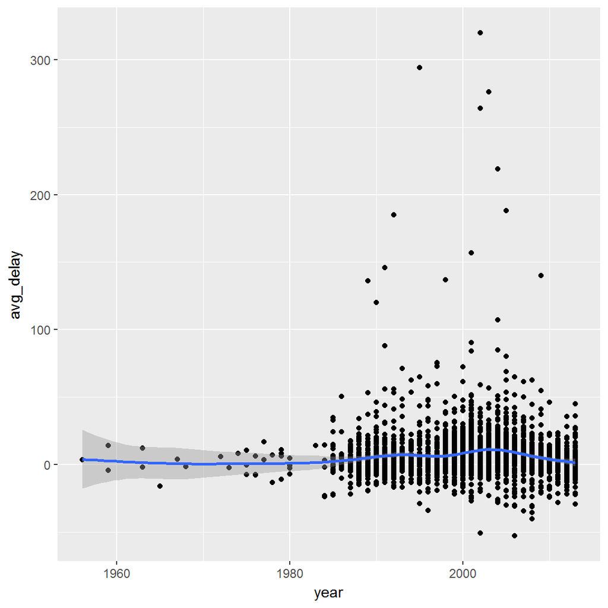

```r
planes_avg_delay <- planes %>%
  select(tailnum, year) %>%
  left_join(flights, "tailnum") %>%
  group_by(tailnum, year.x) %>%
  rename(year = year.x) %>%
  summarise(avg_delay = mean(arr_delay, na.rm = TRUE))

ggplot(planes_avg_delay, aes(year, avg_delay)) +
  geom_point() +
  geom_smooth()
```

It appears not.

4. What weather conditions make it more likely to see a delay?

I think rain and low visibility would increase the likelihood of delay.

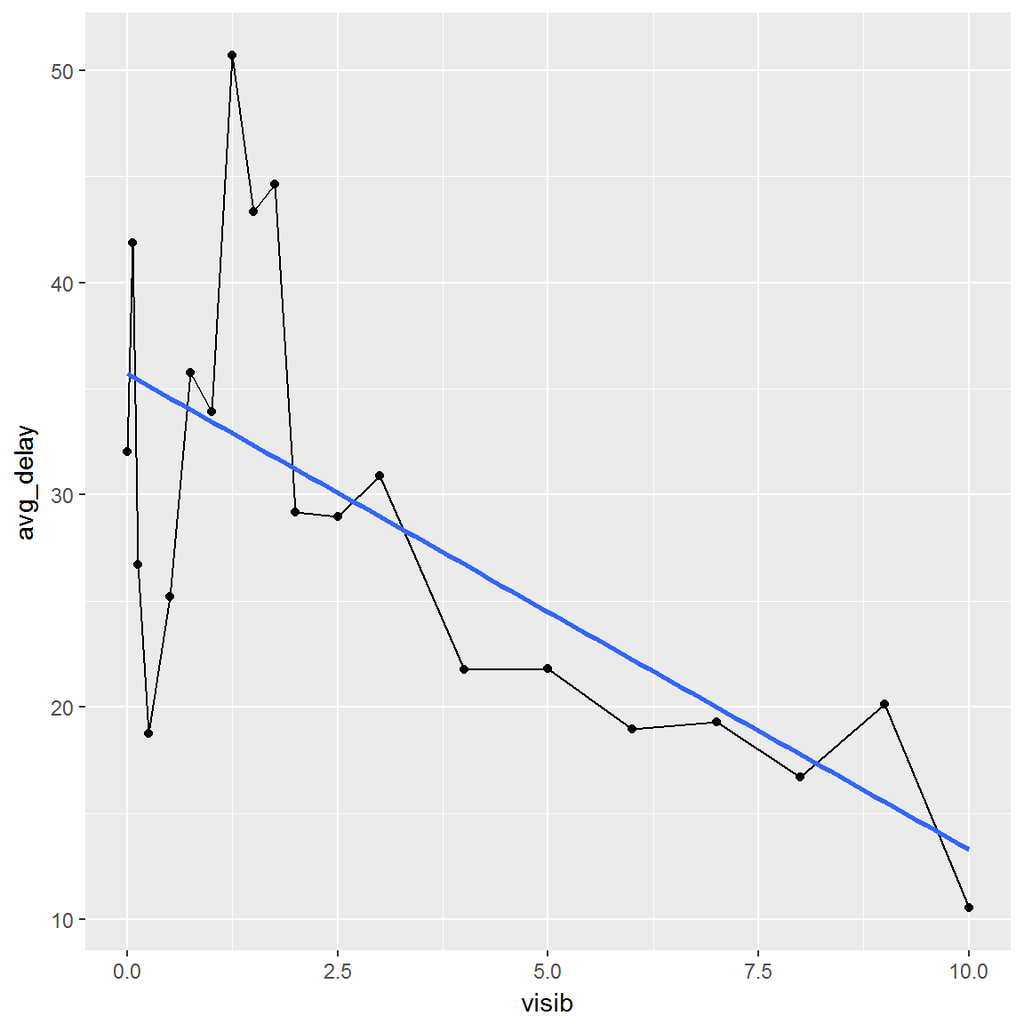

```r
flights_weather <- flights %>%
  inner_join(weather, c("origin", "year", "month", "day", "hour"))

flights_weather %>%
  group_by(visib) %>%
  summarise(avg_delay = mean(dep_delay, na.rm = TRUE)) %>%
  ggplot(aes(visib, avg_delay)) +
    geom_point() +
    geom_line() +
    geom_smooth(method = lm, se = FALSE)
```

As visibility increases, the average delay decreases.

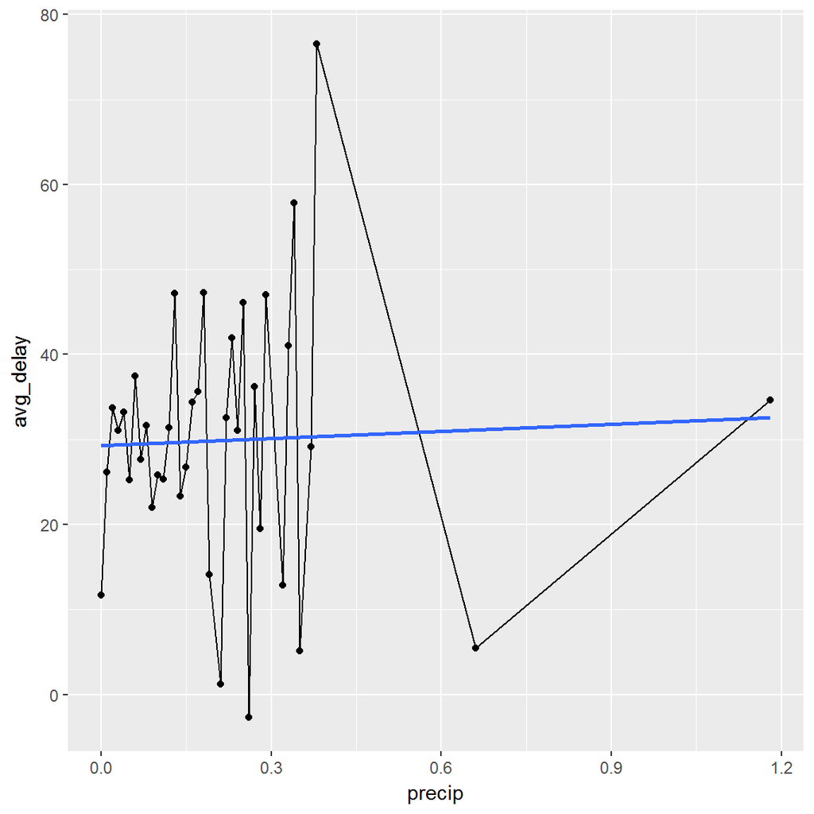

```r
flights_weather %>%
  group_by(precip) %>%
  summarise(avg_delay = mean(dep_delay, na.rm = TRUE)) %>%
  ggplot(aes(precip, avg_delay)) +
    geom_point() +
    geom_line() +
    geom_smooth(method = lm, se = FALSE)
```

The relationship between rainfall and average delay is less clear.

5. What happened on June 13 2013? Display the spatial pattern of delays, and then use Google to cross-reference with the weather.

There were a large series of storms in the south-east.

```r
flights %>%
  filter(month == 6, day == 13) %>%
  group_by(hour) %>%
  summarise(avg_delay = mean(dep_delay, na.rm = TRUE))
```

```
## # A tibble: 19 x 2
##     hour  avg_delay
##    <dbl>      <dbl>
##  1     5  -2.833333
##  2     6   3.542169
##  3     7   2.811594
##  4     8   7.913043
##  5     9  23.245283
##  6    10  27.818182
##  7    11  35.615385
##  8    12  61.340426
##  9    13  51.804348
## 10    14  61.543860
## 11    15  59.169231
## 12    16  52.000000
## 13    17  63.774648
## 14    18  70.000000
## 15    19  92.946429
## 16    20  87.897959
## 17    21  83.320000
## 18    22 103.111111
## 19    23  25.333333
```

By mid-morning there were significant delays. This continued into the evening.

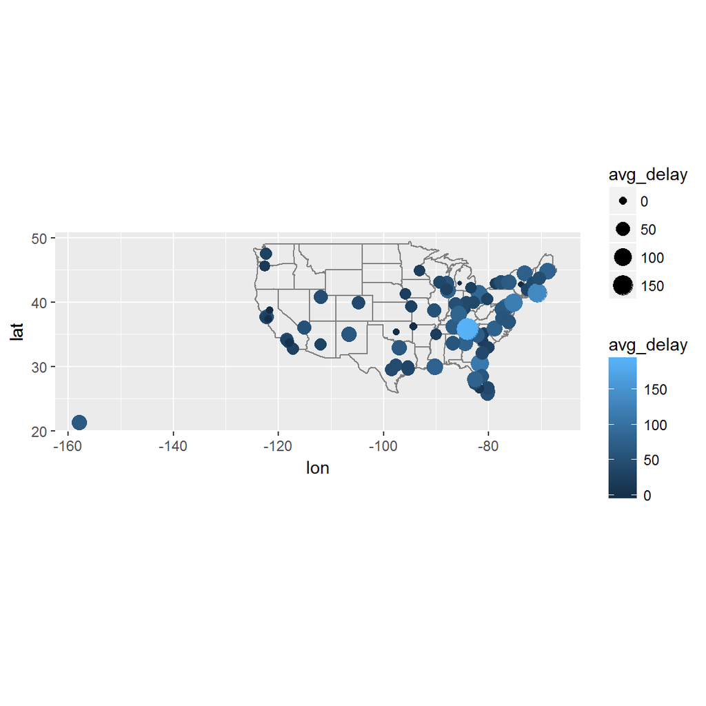

```r
flights %>%
  filter(month == 6, day == 13) %>%
  group_by(dest) %>%
  summarise(avg_delay = mean(dep_delay, na.rm = TRUE)) %>%
  inner_join(airports, by = c("dest" = "faa")) %>%
    ggplot(aes(lon, lat)) +
      borders("state") +
      geom_point(aes(colour = avg_delay, size = avg_delay)) +
      coord_quickmap()
```

## 13.5.1 Exercises

1. What does it mean for a flight to have a missing `tailnum`? What do the tail numbers that don’t have a matching record in `planes` have in common? (Hint: one variable explains ~90% of the problems.)

```r
flights %>%
  anti_join(planes, by = "tailnum")
```

```
## # A tibble: 52,606 x 19
##     year month   day dep_time sched_dep_time dep_delay arr_time
##    <int> <int> <int>    <int>          <int>     <dbl>    <int>
##  1  2013     1     1      558            600        -2      753
##  2  2013     1     1      559            600        -1      941
##  3  2013     1     1      600            600         0      837
##  4  2013     1     1      602            605        -3      821
##  5  2013     1     1      608            600         8      807
##  6  2013     1     1      611            600        11      945
##  7  2013     1     1      623            610        13      920
##  8  2013     1     1      624            630        -6      840
##  9  2013     1     1      628            630        -2     1137
## 10  2013     1     1      629            630        -1      824
## # ... with 52,596 more rows, and 12 more variables: sched_arr_time <int>,
## #   arr_delay <dbl>, carrier <chr>, flight <int>, tailnum <chr>,
## #   origin <chr>, dest <chr>, air_time <dbl>, distance <dbl>, hour <dbl>,
## #   minute <dbl>, time_hour <dttm>
```

Many of the flights without a tail number in `planes` appear to be American Airlines (`AA`) or Envoy Air (`MQ`).

```r
flights %>%
  anti_join(planes, by = "tailnum") %>%
  group_by(carrier) %>%
  summarise(count = n())
```

```
## # A tibble: 10 x 2
##    carrier count
##      <chr> <int>
##  1      9E  1044
##  2      AA 22558
##  3      B6   830
##  4      DL   110
##  5      F9    50
##  6      FL   187
##  7      MQ 25397
##  8      UA  1693
##  9      US   699
## 10      WN    38
```

```r
flights %>%
  anti_join(planes, by = "tailnum") %>%
  nrow()
```

```
## [1] 52606
```

Specifically, about 90% of flights.

2. Filter flights to only show flights with planes that have flown at least 100 flights.

```r
flights_100 <- flights %>%
  group_by(tailnum) %>%
  count() %>%
  filter(n >= 100 & tailnum != "NA") %>%
  arrange(desc(n))

flights %>%
  semi_join(flights_100, by = "tailnum")
```

```
## # A tibble: 228,390 x 19
##     year month   day dep_time sched_dep_time dep_delay arr_time
##    <int> <int> <int>    <int>          <int>     <dbl>    <int>
##  1  2013     1     1      517            515         2      830
##  2  2013     1     1      533            529         4      850
##  3  2013     1     1      544            545        -1     1004
##  4  2013     1     1      554            558        -4      740
##  5  2013     1     1      555            600        -5      913
##  6  2013     1     1      557            600        -3      709
##  7  2013     1     1      557            600        -3      838
##  8  2013     1     1      558            600        -2      849
##  9  2013     1     1      558            600        -2      853
## 10  2013     1     1      558            600        -2      923
## # ... with 228,380 more rows, and 12 more variables: sched_arr_time <int>,
## #   arr_delay <dbl>, carrier <chr>, flight <int>, tailnum <chr>,
## #   origin <chr>, dest <chr>, air_time <dbl>, distance <dbl>, hour <dbl>,
## #   minute <dbl>, time_hour <dttm>
```

3. Combine `fueleconomy::vehicles` and `fueleconomy::common` to find only the records for the most common models.

```r
fueleconomy::vehicles %>%
  semi_join(fueleconomy::common, by = c("make", "model"))
```

```
## # A tibble: 14,531 x 12
##       id  make   model  year           class           trans
##    <int> <chr>   <chr> <int>           <chr>           <chr>
##  1  1833 Acura Integra  1986 Subcompact Cars Automatic 4-spd
##  2  1834 Acura Integra  1986 Subcompact Cars    Manual 5-spd
##  3  3037 Acura Integra  1987 Subcompact Cars Automatic 4-spd
##  4  3038 Acura Integra  1987 Subcompact Cars    Manual 5-spd
##  5  4183 Acura Integra  1988 Subcompact Cars Automatic 4-spd
##  6  4184 Acura Integra  1988 Subcompact Cars    Manual 5-spd
##  7  5303 Acura Integra  1989 Subcompact Cars Automatic 4-spd
##  8  5304 Acura Integra  1989 Subcompact Cars    Manual 5-spd
##  9  6442 Acura Integra  1990 Subcompact Cars Automatic 4-spd
## 10  6443 Acura Integra  1990 Subcompact Cars    Manual 5-spd
## # ... with 14,521 more rows, and 6 more variables: drive <chr>, cyl <int>,
## #   displ <dbl>, fuel <chr>, hwy <int>, cty <int>
```

4. Find the 48 hours (over the course of the whole year) that have the worst delays. Cross-reference it with the `weather` data. Can you see any patterns?
5. What does `anti_join(flights, airports, by = c("dest" = "faa"))` tell you? What does `anti_join(airports, flights, by = c("faa" = "dest"))` tell you?

```r
anti_join(flights, airports, by = c("dest" = "faa"))
```

```
## # A tibble: 7,602 x 19
##     year month   day dep_time sched_dep_time dep_delay arr_time
##    <int> <int> <int>    <int>          <int>     <dbl>    <int>
##  1  2013     1     1      544            545        -1     1004
##  2  2013     1     1      615            615         0     1039
##  3  2013     1     1      628            630        -2     1137
##  4  2013     1     1      701            700         1     1123
##  5  2013     1     1      711            715        -4     1151
##  6  2013     1     1      820            820         0     1254
##  7  2013     1     1      820            820         0     1249
##  8  2013     1     1      840            845        -5     1311
##  9  2013     1     1      909            810        59     1331
## 10  2013     1     1      913            918        -5     1346
## # ... with 7,592 more rows, and 12 more variables: sched_arr_time <int>,
## #   arr_delay <dbl>, carrier <chr>, flight <int>, tailnum <chr>,
## #   origin <chr>, dest <chr>, air_time <dbl>, distance <dbl>, hour <dbl>,
## #   minute <dbl>, time_hour <dttm>
```

The destination of these flights is unknown (i.e., the airport does not appear in `airports`). They could be international flights.

```r
anti_join(airports, flights, by = c("faa" = "dest"))
```

```
## # A tibble: 1,357 x 8
##      faa                           name      lat        lon   alt    tz
##    <chr>                          <chr>    <dbl>      <dbl> <int> <dbl>
##  1   04G              Lansdowne Airport 41.13047  -80.61958  1044    -5
##  2   06A  Moton Field Municipal Airport 32.46057  -85.68003   264    -6
##  3   06C            Schaumburg Regional 41.98934  -88.10124   801    -6
##  4   06N                Randall Airport 41.43191  -74.39156   523    -5
##  5   09J          Jekyll Island Airport 31.07447  -81.42778    11    -5
##  6   0A9 Elizabethton Municipal Airport 36.37122  -82.17342  1593    -5
##  7   0G6        Williams County Airport 41.46731  -84.50678   730    -5
##  8   0G7  Finger Lakes Regional Airport 42.88356  -76.78123   492    -5
##  9   0P2   Shoestring Aviation Airfield 39.79482  -76.64719  1000    -5
## 10   0S9          Jefferson County Intl 48.05381 -122.81064   108    -8
## # ... with 1,347 more rows, and 2 more variables: dst <chr>, tzone <chr>
```

6. You might expect that there’s an implicit relationship between plane and airline, because each plane is flown by a single airline. Confirm or reject this hypothesis using the tools you’ve learned above.

```r
flights_carrier <- flights %>%
  group_by(tailnum, carrier) %>%
  count() %>%
  arrange(tailnum)
flights_carrier
```

```
## # A tibble: 4,067 x 3
## # Groups:   tailnum, carrier [4,067]
##    tailnum carrier     n
##      <chr>   <chr> <int>
##  1  D942DN      DL     4
##  2  N0EGMQ      MQ   371
##  3  N10156      EV   153
##  4  N102UW      US    48
##  5  N103US      US    46
##  6  N104UW      US    47
##  7  N10575      EV   289
##  8  N105UW      US    45
##  9  N107US      US    41
## 10  N108UW      US    60
## # ... with 4,057 more rows
```

```r
flights_carrier %>%
  group_by(tailnum) %>%
  count() %>%
  filter(nn > 1)
```

```
## # A tibble: 18 x 2
## # Groups:   tailnum [18]
##    tailnum    nn
##      <chr> <int>
##  1  N146PQ     2
##  2  N153PQ     2
##  3  N176PQ     2
##  4  N181PQ     2
##  5  N197PQ     2
##  6  N200PQ     2
##  7  N228PQ     2
##  8  N232PQ     2
##  9  N933AT     2
## 10  N935AT     2
## 11  N977AT     2
## 12  N978AT     2
## 13  N979AT     2
## 14  N981AT     2
## 15  N989AT     2
## 16  N990AT     2
## 17  N994AT     2
## 18    <NA>     7
```

There are a number of planes that have been flown by multiple airlines. However, the majority of planes have had a single airline.

# 14. Strings

To come…

# 15. Factors

## 15.3.1 Exercises

1. Explore the distribution of `rincome` (reported income). What makes the default bar chart hard to understand? How could you improve the plot?

```r
summary(gss_cat$rincome)
```

```
##      No answer     Don't know        Refused $25000 or more $20000 - 24999
##            183            267            975           7363           1283
## $15000 - 19999 $10000 - 14999  $8000 to 9999  $7000 to 7999  $6000 to 6999
##           1048           1168            340            188            215
##  $5000 to 5999  $4000 to 4999  $3000 to 3999  $1000 to 2999       Lt $1000
##            227            226            276            395            286
## Not applicable
##           7043
```

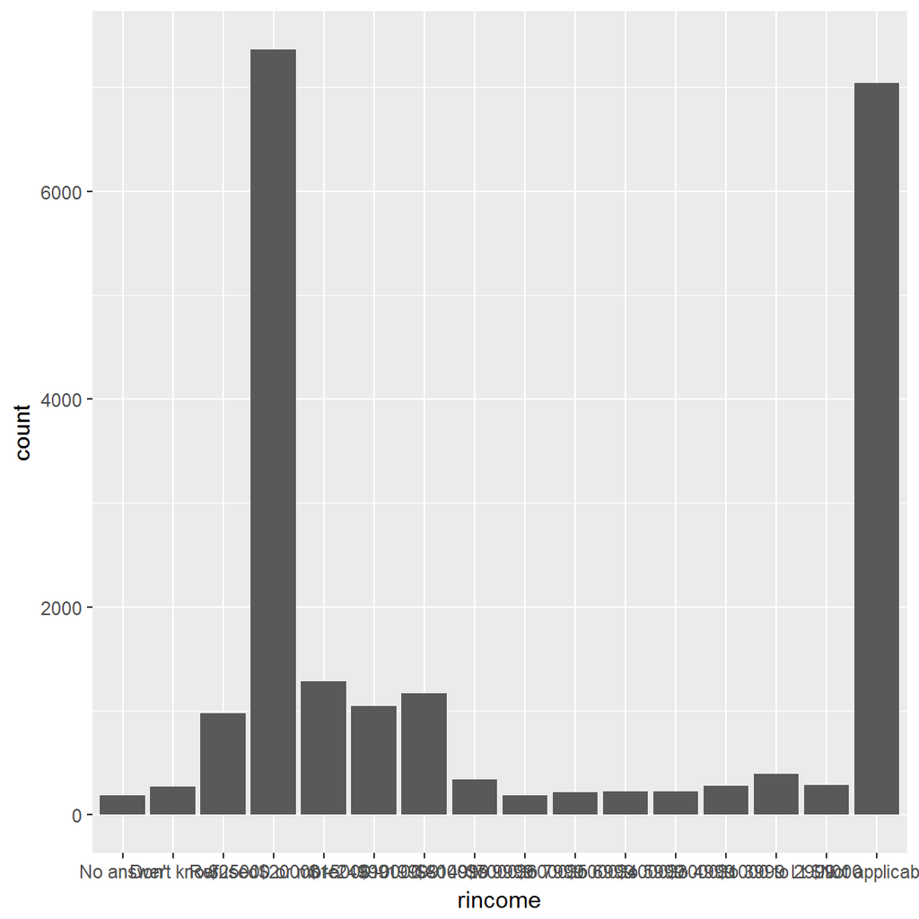

```r
ggplot(gss_cat, aes(rincome)) +
  geom_bar()
```

This plot can be improved by rotating the labels on the x-axis:

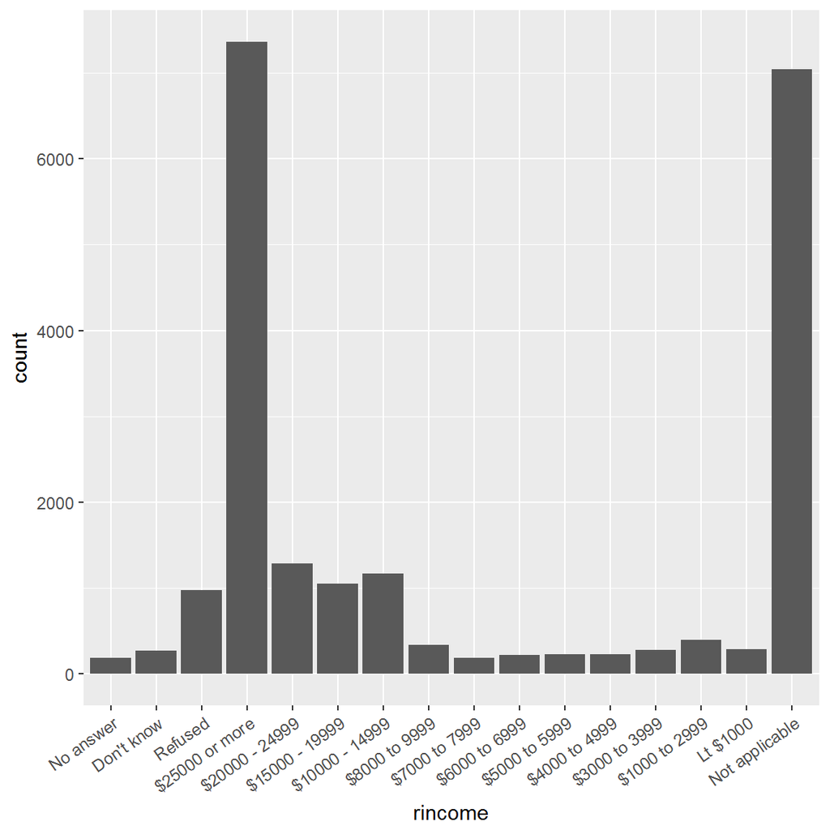

```r
ggplot(gss_cat, aes(rincome)) +
  geom_bar() +
  theme(axis.text.x = element_text(angle = 35, hjust = 1))
```

It would also be better if the categories on the x-axis were ordered from smallest to largest. To do this, you would have to modify the order of the factor levels. The following categories can also be combined: “No answer”, “Don’t know”, “Refused”, and “Not applicable”.

2. What is the most common `relig` in this survey? What’s the most common `partyid`?

```r
gss_cat %>%
  count(relig) %>%
  arrange(desc(n)) %>%
  head(1)
```

```
## # A tibble: 1 x 2
##        relig     n
##       <fctr> <int>
## 1 Protestant 10846
```

```r
gss_cat %>%
  count(partyid) %>%
  arrange(desc(n)) %>%
  head(1)
```

```
## # A tibble: 1 x 2
##       partyid     n
##        <fctr> <int>
## 1 Independent  4119
```

“Protestant”" is the most common religion.

The most common party affiliation is “Independent”.

3. Which `relig` does `denom` (denomination) apply to? How can you find out with a table? How can you find out with a visualisation?

```r
levels(gss_cat$denom)
```

```
##  [1] "No answer"            "Don't know"           "No denomination"
##  [4] "Other"                "Episcopal"            "Presbyterian-dk wh"
##  [7] "Presbyterian, merged" "Other presbyterian"   "United pres ch in us"
## [10] "Presbyterian c in us" "Lutheran-dk which"    "Evangelical luth"
## [13] "Other lutheran"       "Wi evan luth synod"   "Lutheran-mo synod"
## [16] "Luth ch in america"   "Am lutheran"          "Methodist-dk which"
## [19] "Other methodist"      "United methodist"     "Afr meth ep zion"
## [22] "Afr meth episcopal"   "Baptist-dk which"     "Other baptists"
## [25] "Southern baptist"     "Nat bapt conv usa"    "Nat bapt conv of am"
## [28] "Am bapt ch in usa"    "Am baptist asso"      "Not applicable"
```

```r
no_denom <- gss_cat %>%
  filter(!denom %in% c("No answer", "Don't know", "No denomination", "Not applicable", "Refused"))
```

```r
no_denom %>%
  count(relig)
```

```
## # A tibble: 1 x 2
##        relig     n
##       <fctr> <int>
## 1 Protestant  9559
```

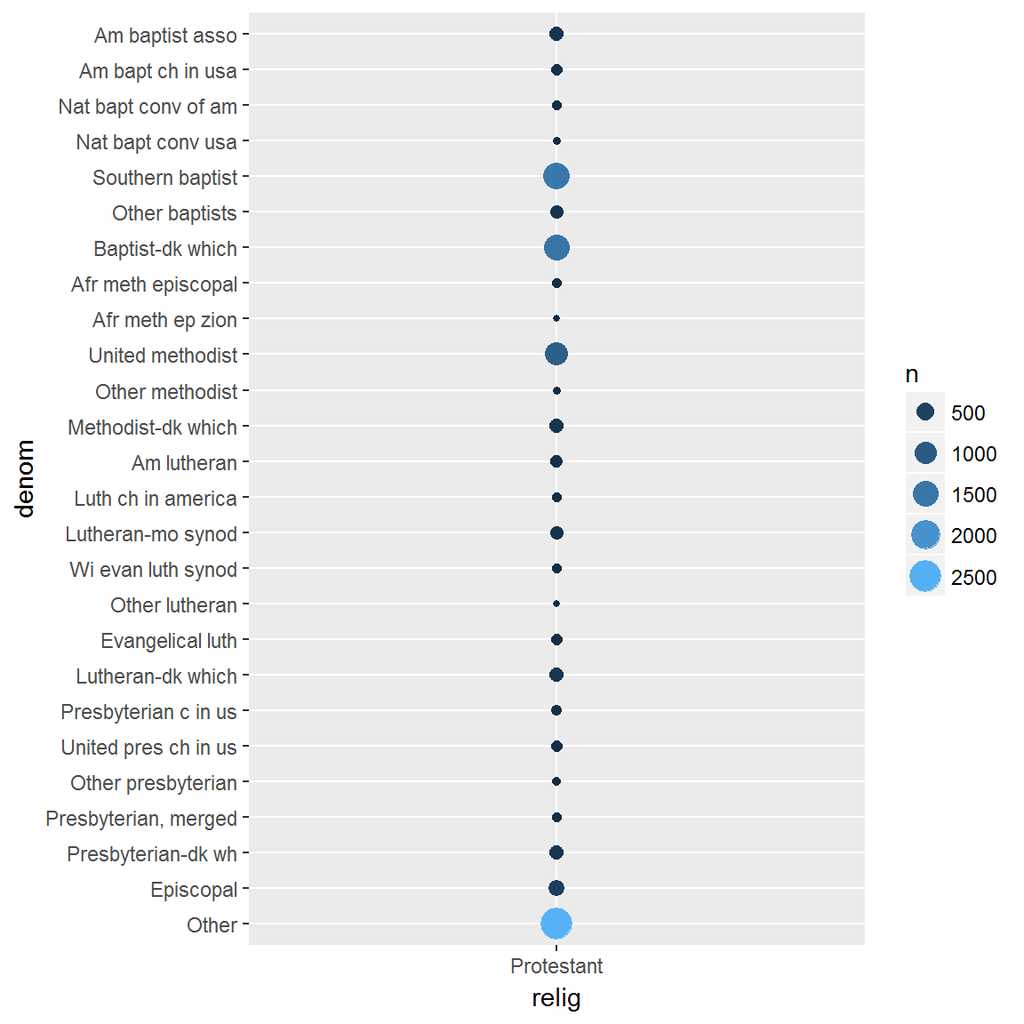

```r
ggplot(no_denom, aes(relig, denom)) +
  geom_count(aes(colour = ..n.., size = ..n..)) +
  guides(colour = 'legend')
```

Denomination applies to “Protestant”.

## 15.4.1 Exercises

1. There are some suspiciously high numbers in `tvhours`. Is the mean a good summary?

```r
summary(gss_cat$tvhours)
```

```
##    Min. 1st Qu.  Median    Mean 3rd Qu.    Max.    NA's
##   0.000   1.000   2.000   2.981   4.000  24.000   10146
```

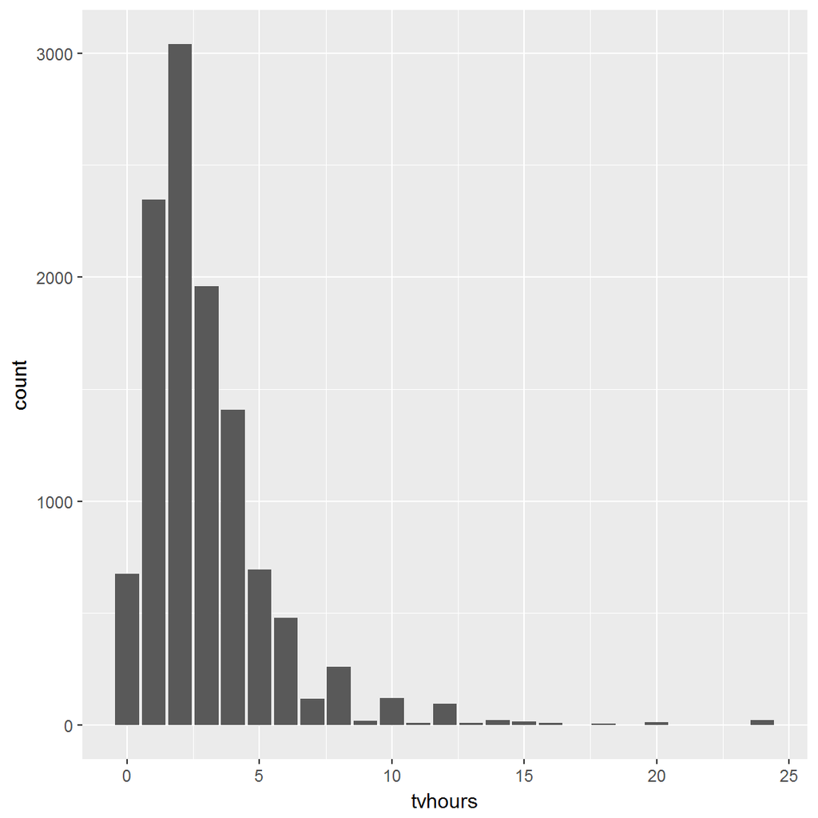

```r
ggplot(gss_cat, aes(tvhours)) +
  geom_bar()
```

```r
gss_cat %>%
  count(tvhours) %>%
  arrange(desc(tvhours))
```

```
## # A tibble: 25 x 2
##    tvhours     n
##      <int> <int>
##  1      24    22
##  2      23     1
##  3      22     2
##  4      21     2
##  5      20    14
##  6      18     7
##  7      17     2
##  8      16    10
##  9      15    17
## 10      14    24
## # ... with 15 more rows
```

It is unlikely that people are watching 24 hours of tv per day. As seen in the bar plot, `tvhours` is skewed to the right due to the presence of these extreme values. The median would be a better summary of the data, because, unlike the mean, it is largely unaffected by outliers.

2. For each factor in `gss_cat` identify whether the order of the levels is arbitrary or principled.

```r
glimpse(gss_cat)
```

```
## Observations: 21,483
## Variables: 9
## $ year    <int> 2000, 2000, 2000, 2000, 2000, 2000, 2000, 2000, 2000, ...
## $ marital <fctr> Never married, Divorced, Widowed, Never married, Divo...
## $ age     <int> 26, 48, 67, 39, 25, 25, 36, 44, 44, 47, 53, 52, 52, 51...
## $ race    <fctr> White, White, White, White, White, White, White, Whit...
## $ rincome <fctr> $8000 to 9999, $8000 to 9999, Not applicable, Not app...
## $ partyid <fctr> Ind,near rep, Not str republican, Independent, Ind,ne...
## $ relig   <fctr> Protestant, Protestant, Protestant, Orthodox-christia...
## $ denom   <fctr> Southern baptist, Baptist-dk which, No denomination, ...
## $ tvhours <int> 12, NA, 2, 4, 1, NA, 3, NA, 0, 3, 2, NA, 1, NA, 1, 7, ...
```

```r
levels(gss_cat$marital)
```

```
## [1] "No answer"     "Never married" "Separated"     "Divorced"
## [5] "Widowed"       "Married"
```

```r
levels(gss_cat$rincome)
```

```
##  [1] "No answer"      "Don't know"     "Refused"        "$25000 or more"
##  [5] "$20000 - 24999" "$15000 - 19999" "$10000 - 14999" "$8000 to 9999"
##  [9] "$7000 to 7999"  "$6000 to 6999"  "$5000 to 5999"  "$4000 to 4999"
## [13] "$3000 to 3999"  "$1000 to 2999"  "Lt $1000"       "Not applicable"
```

`marital`, `race` `partyid`, `relig`, and `denom` are arbitrary (i.e., nominal). `rincome` is principled (i.e., ordinal).

3. Why did moving “Not applicable” to the front of the levels move it to the bottom of the plot?

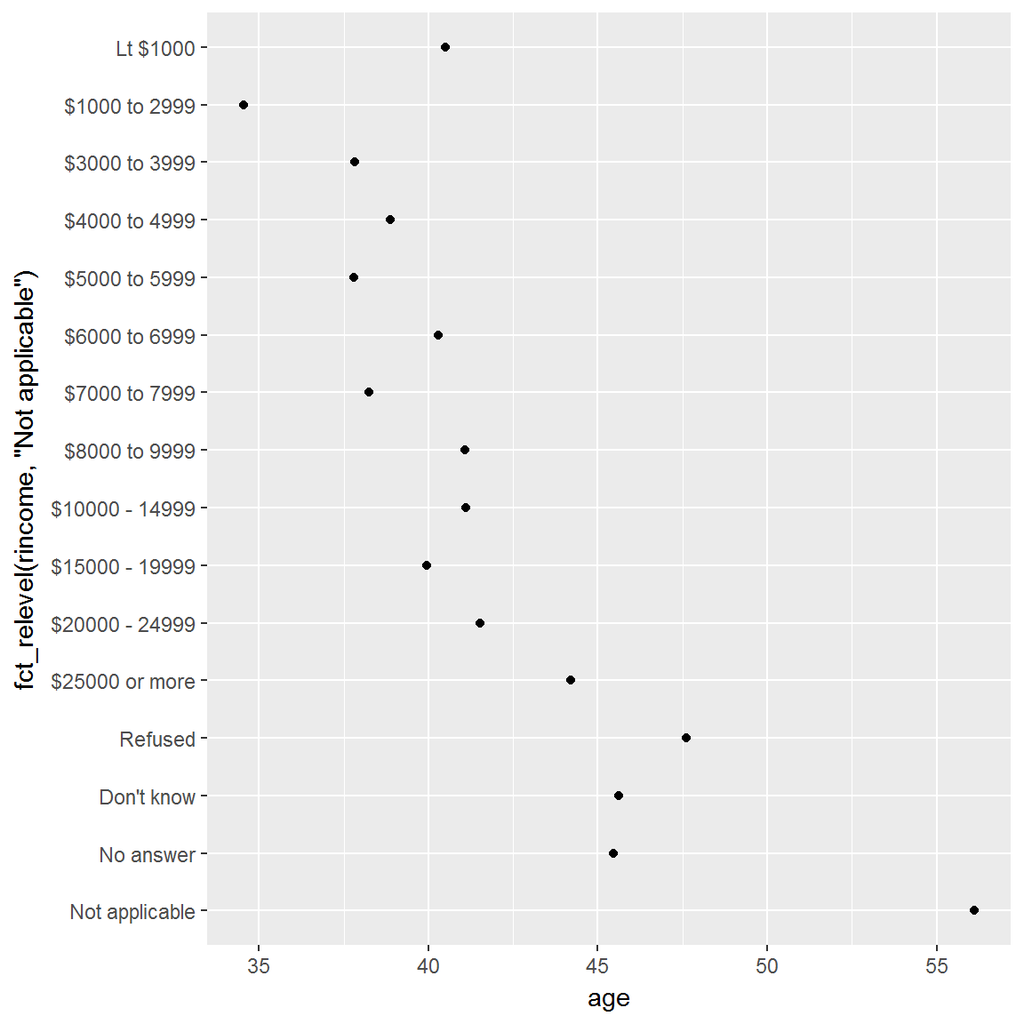

```r
rincome_summary <- gss_cat %>%
  group_by(rincome) %>%
  summarise(
    age = mean(age, na.rm = TRUE),
    tvhours = mean(tvhours, na.rm = TRUE),
    n = n()
  )

ggplot(rincome_summary, aes(age, fct_relevel(rincome, "Not applicable"))) +
  geom_point()
```

Because `fct_relevel` gives “Not applicable” an integer value of 1:

```r
rincome_levels <- fct_relevel(rincome_summary$rincome, "Not applicable")
levels(rincome_levels)
```

```
##  [1] "Not applicable" "No answer"      "Don't know"     "Refused"
##  [5] "$25000 or more" "$20000 - 24999" "$15000 - 19999" "$10000 - 14999"
##  [9] "$8000 to 9999"  "$7000 to 7999"  "$6000 to 6999"  "$5000 to 5999"
## [13] "$4000 to 4999"  "$3000 to 3999"  "$1000 to 2999"  "Lt $1000"
```

## 15.5.1 Exercises

1. How have the proportions of people identifying as Democrat, Republican, and Independent changed over time?

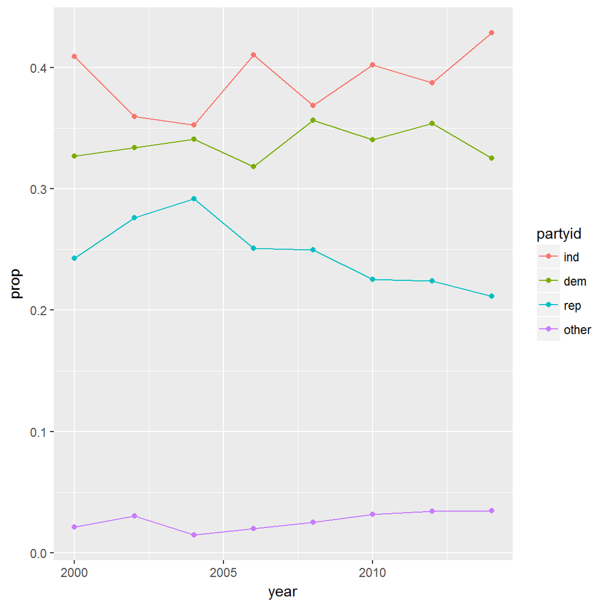

```r
partyid_clean <- gss_cat %>%
  mutate(partyid = fct_collapse(
    partyid,
    other = c("No answer", "Don't know", "Other party"),
    rep = c("Strong republican", "Not str republican"),
    ind = c("Ind,near rep", "Independent", "Ind,near dem"),
    dem = c("Not str democrat", "Strong democrat")
  ))

partyid_counts <- partyid_clean %>%
  count(year, partyid) %>%
  group_by(year) %>%
  mutate(prop = n / sum(n))

ggplot(partyid_counts, aes(x = year, y = prop, colour = fct_reorder2(
  partyid, year, prop
))) +
  geom_point() +
  geom_line() +
  labs(colour = "partyid")
```

There appears to be less people identifying as Republican over time. In comparison, the proportion of people identifying as Independent appears to be increasing, while the number of Democrats appear about the same.

There is also a slight increase in the number of people identifying as Other since around 2005.

2. How could you collapse `rincome` into a small set of categories?

```r
gss_cat %>%
  count(rincome)
```

```
## # A tibble: 16 x 2
##           rincome     n
##            <fctr> <int>
##  1      No answer   183
##  2     Don't know   267
##  3        Refused   975
##  4 $25000 or more  7363
##  5 $20000 - 24999  1283
##  6 $15000 - 19999  1048
##  7 $10000 - 14999  1168
##  8  $8000 to 9999   340
##  9  $7000 to 7999   188
## 10  $6000 to 6999   215
## 11  $5000 to 5999   227
## 12  $4000 to 4999   226
## 13  $3000 to 3999   276
## 14  $1000 to 2999   395
## 15       Lt $1000   286
## 16 Not applicable  7043
```

```r
gss_cat %>%
  mutate(rincome = fct_lump(rincome, n = 5)) %>%
  count(rincome, sort = TRUE) %>%
  mutate(rincome = fct_recode(
    rincome,
    "Less than $10000" = "Other"
  ))
```

```
## # A tibble: 6 x 2
##            rincome     n
##             <fctr> <int>
## 1   $25000 or more  7363
## 2   Not applicable  7043
## 3 Less than $10000  3578
## 4   $20000 - 24999  1283
## 5   $10000 - 14999  1168
## 6   $15000 - 19999  1048
```

# 16. Dates and times

## 16.2.4 Exercises

1. What happens if you parse a string that contains invalid dates?

   ```r
   ymd(c("2010-10-10", "bananas"))
   ```

The invalid dates will be `NA`.

2. What does the `tzone` argument to `today()` do? Why is it important?

`tzone` specifies which time zone you would like to find the current date of.

3. Use the appropriate lubridate function to parse each of the following dates:

   ```r
   d1 <- "January 1, 2010"
   d2 <- "2015-Mar-07"
   d3 <- "06-Jun-2017"
   d4 <- c("August 19 (2015)", "July 1 (2015)")
   d5 <- "12/30/14" # Dec 30, 2014
   ```

```r
mdy(d1)
```

```
## [1] "2010-01-01"
```

```r
ymd(d2)
```

```
## [1] "2015-03-07"
```

```r
dmy(d3)
```

```
## [1] "2017-06-06"
```

```r
mdy(d4)
```

```
## [1] "2015-08-19" "2015-07-01"
```

```r
mdy(d5)
```

```
## [1] "2014-12-30"
```

## 16.3.4 Exercises

1. How does the distribution of flight times within a day change over the course of the year?

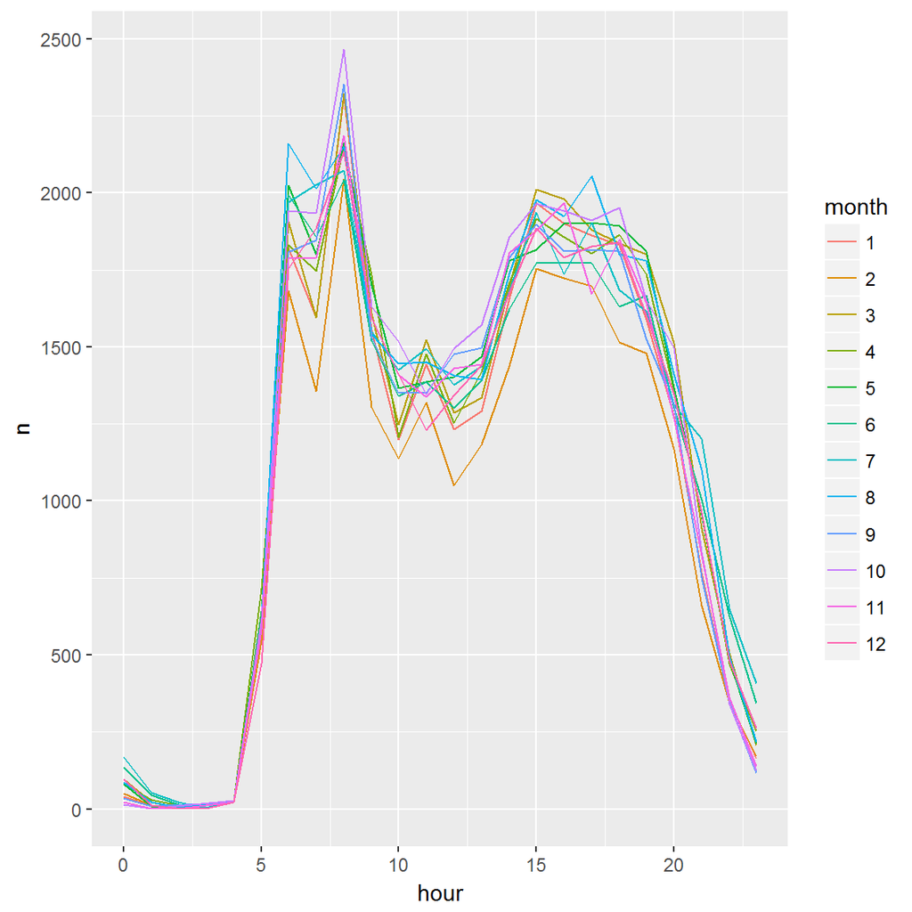

```r
flights_dt %>%
  mutate(hour = hour(dep_time), month = factor(month(dep_time))) %>%
  group_by(hour, month) %>%
  summarise(
    n = n()
  ) %>%
  ggplot(aes(x = hour, y = n, colour = month)) +
    geom_line()
```

2. Compare `dep_time`, `sched_dep_time` and `dep_delay`. Are they consistent? Explain your findings.
3. Compare `air_time` with the duration between the departure and arrival. Explain your findings. (Hint: consider the location of the airport.)
4. How does the average delay time change over the course of a day? Should you use `dep_time` or `sched_dep_time`? Why?
5. On what day of the week should you leave if you want to minimise the chance of a delay?

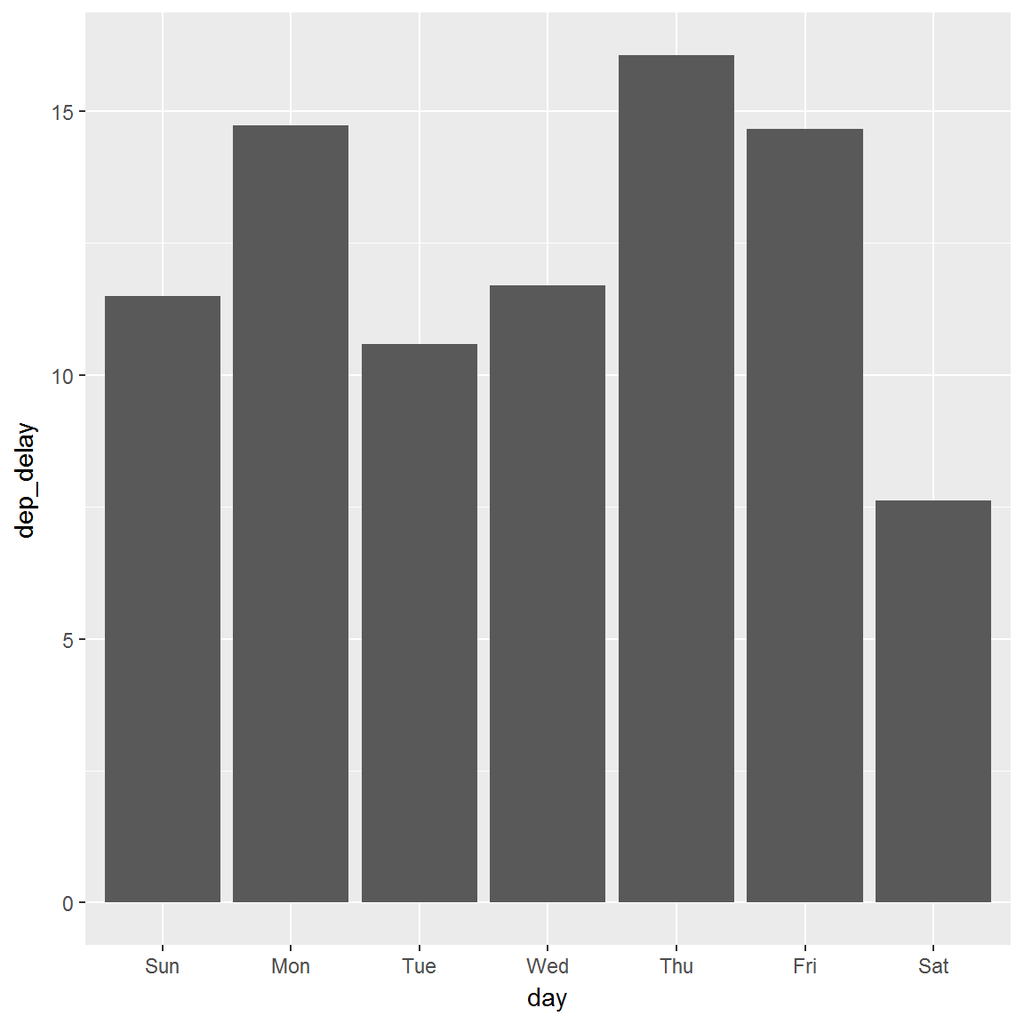

```r
flights_dt %>%
  mutate(day = wday(sched_dep_time, label = TRUE)) %>%
  group_by(day) %>%
  summarise(dep_delay = mean(dep_delay)) %>%
  ggplot(aes(day, dep_delay)) +
    geom_col()
```

Saturday.

6. What makes the distribution of `diamonds$carat` and `flights$sched_dep_time` similar?
7. Confirm my hypothesis that the early departures of flights in minutes 20-30 and 50-60 are caused by scheduled flights that leave early. Hint: create a binary variable that tells you whether or not a flight was delayed.